# Coral Physiology Following Reciprocal Transplant

Serena Hackerott

1/1/2024

# Setup

### Load Packages

```r
##Install Packages if Needed
if (!require("ggplot2")) install.packages("ggplot2")
if (!require("cowplot")) install.packages("cowplot")
if (!require("Rmisc")) install.packages("Rmisc")
if (!require("lme4")) install.packages("lme4")
if (!require("lmerTest")) install.packages("lmerTest")
if (!require("vegan")) install.packages("vegan")
if (!require("corrplot")) install.packages("corrplot")
if (!require("DHARMa")) install.packages("DHARMa")
if (!require("effectsize")) install.packages("effectsize")
if (!require("emmeans")) install.packages("emmeans")
if (!require("Hmisc")) install.packages("Hmisc")
if (!require("dplyr")) install.packages("dplyr")
if (!require("tidyr")) install.packages("tidyr")
if (!require("ggpubr")) install.packages("ggpubr")

##Load Packages
library(ggplot2) #Required for ggplots
library(cowplot) #Required for plotting panel figures
library(Rmisc) #Required for SummarySE function
library(lme4) #Required for mixed effects modeling
library(lmerTest) #Required for p values with lme4 model summaries
library(vegan) #Required for multivariate analysis PERM
library(corrplot) #Required for correlation plot
library(DHARMa) #Required to check residuals of mixed effects models
library(effectsize) #Required for eta_squared effect sizes
library(emmeans) #Required for pairwise comparisons
library(Hmisc) #Required for correlations
library(dplyr) #Required for dataframe organization
library(tidyr) #Required for dataframe organization
library(ggpubr) #Required for stat brackets
```

### Graphing Parameters

```r
#Note: Run "Graphing Parameters" section from 01_ExperimentalSetup.Rmd file
```

# Sample Data and Metadata

### Load and Organize Data

```r
##Load Data
#Note: Physiological metrics calculated in 02_PhysiologyMetrics.R file
Coral<-read.csv("Outputs/CoralData.csv", header=TRUE)

##Set factor variables
Coral$TimeP<-factor(Coral$TimeP, levels=c("TP1", "TP2", "TP3", "TP4"))
Coral$Site<-factor(Coral$Site, levels=c("KL", "SS"))
Coral$Genotype<-factor(Coral$Genotype, levels=c("AC8", "AC10", "AC12"))
Coral$Orig<-factor(Coral$Orig, levels=c("N", "T"))
Coral$Origin<-factor(Coral$Origin, levels=c("Native", "Transplant"))
Coral$Site.Orig<-factor(Coral$Site.Orig, levels=c("KL.N", "KL.T", "SS.N", "SS.T"))
```

# Multivariate Analysis

### adonis OmegaSq Function

```r
#' Calculate (partial) Omega-squared (effect-size calculation) for PERMANOVA and add it to the input object
#'
#' @param adonisOutput An adonis object
#' @param partial Should partial omega-squared be calculated (sample size adjusted). Default TRUE
#' @return Original adonis object with the (partial) Omega-squared values added
#' @import vegan
#' @export
adonis_OmegaSq <- function(adonisOutput, partial = TRUE){
    if(!(is(adonisOutput, "adonis") || is(adonisOutput, "anova.cca")))
        stop("Input should be an adonis object")
    if (is(adonisOutput, "anova.cca")) {
        aov_tab <- adonisOutput
        aov_tab$MeanSqs <- aov_tab$SumOfSqs / aov_tab$Df
        aov_tab$MeanSqs[length(aov_tab$Df)] <- NA
    } else {
        aov_tab <- adonisOutput$aov.tab
    }
    heading <- attr(aov_tab, "heading")
    MS_res <- aov_tab[pmatch("Residual", rownames(aov_tab)), "MeanSqs"]
    SS_tot <- aov_tab[rownames(aov_tab) == "Total", "SumsOfSqs"]
    N <- aov_tab[rownames(aov_tab) == "Total", "Df"] + 1
    if(partial){
        omega <- apply(aov_tab, 1, function(x) (x["Df"]*(x["MeanSqs"]-MS_res))/(x["Df"]*x["MeanSqs"]+(N-x["Df"])*MS_res))
        aov_tab$parOmegaSq <- c(omega[1:(length(omega)-2)], NA, NA)
    } else {
        omega <- apply(aov_tab, 1, function(x) (x["SumsOfSqs"]-x["Df"]*MS_res)/(SS_tot+MS_res))
        aov_tab$OmegaSq <- c(omega[1:(length(omega)-2)], NA, NA)
    }
    if (is(adonisOutput, "adonis"))
        cn_order <- c("Df", "SumsOfSqs", "MeanSqs", "F.Model", "R2",
                      if (partial) "parOmegaSq" else "OmegaSq", "Pr(>F)")
    else
        cn_order <- c("Df", "SumOfSqs", "F", if (partial) "parOmegaSq" else "OmegaSq",
                      "Pr(>F)")
    aov_tab <- aov_tab[, cn_order]
    attr(aov_tab, "names") <- cn_order
    attr(aov_tab, "heading") <- heading
    if (is(adonisOutput, "adonis"))
        adonisOutput$aov.tab <- aov_tab
    else
        adonisOutput <- aov_tab
    return(adonisOutput)
}
```

### Check Correlation

```r
##Remove NA's
names(Coral)
```

```
 [1] "RandN"       "ID"          "TimeP"       "Site"        "Genotype"    "Orig"
 [7] "Origin"      "Set"         "Site.Orig"   "SA_cm2"      "TP_ug.cm2"   "AFDW_mg.cm2"
[13] "Chl_ug.cm2"
```

```r
Coral.rm<-na.omit(Coral)

##Correlation
Phys.cor<-rcorr(as.matrix(Coral.rm[,-c(1:10)]), type="pearson")
Phys.cor
```

```
            TP_ug.cm2 AFDW_mg.cm2 Chl_ug.cm2
TP_ug.cm2        1.00        0.61       0.26
AFDW_mg.cm2      0.61        1.00       0.46
Chl_ug.cm2       0.26        0.46       1.00

n= 190


P
            TP_ug.cm2 AFDW_mg.cm2 Chl_ug.cm2
TP_ug.cm2             0e+00       3e-04
AFDW_mg.cm2 0e+00                 0e+00
Chl_ug.cm2  3e-04     0e+00
```

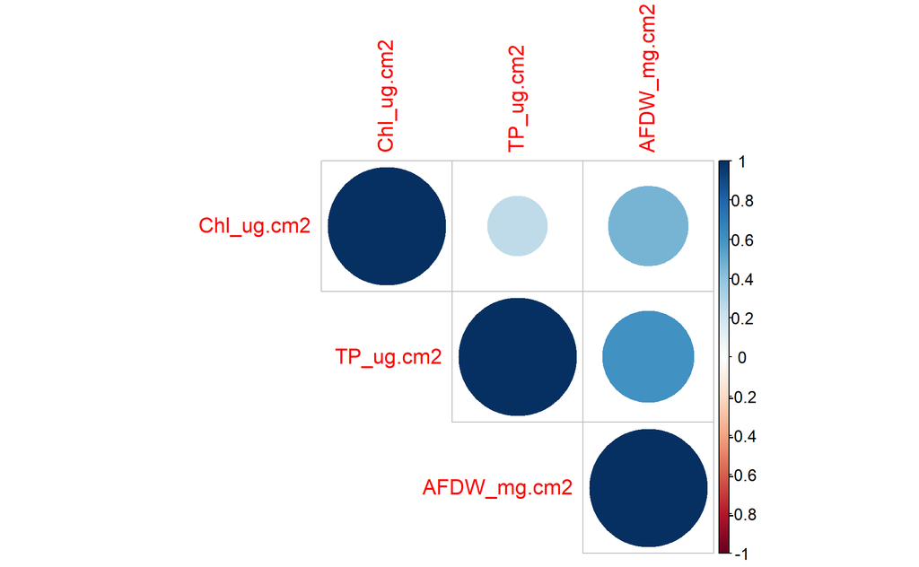

```r
diag(Phys.cor$P)<-0

corrplot(Phys.cor$r, type="upper", order="hclust",
         p.mat = Phys.cor$P, sig.level = 0.01, insig = "blank")
```

### All Timepoints

```r
##Standardize Variables for similar scales
Coral_St <- Coral.rm %>% mutate_at(c("TP_ug.cm2", "AFDW_mg.cm2", "Chl_ug.cm2"), ~(scale(.) %>% as.vector))
```

#### PERMANOVA

Checking for an overall effect of Origin or Site or Time, along with all interactions. Overall effect of Time alone (season) is not of main interest, but is predicted to interact with the effect of Origin as the time post-transplant increases.

```r
##PERMANOVA
Coral.perm<-adonis2(vegdist(Coral_St[,c(11:13)], "euclidean")~ Coral_St$Origin*Coral_St$Site*Coral_St$TimeP, data=Coral_St, strata=Coral_St$Genotype, method="euclidean")

##Effect Size
adonis_OmegaSq(Coral.perm)
```

```
Permutation test for adonis under reduced model
Terms added sequentially (first to last)
Blocks:  strata
Permutation: free
Number of permutations: 999

adonis2(formula = vegdist(Coral_St[, c(11:13)], "euclidean") ~ Coral_St$Origin * Coral_St$Site * Coral_St$TimeP, data = Coral_St, method = "euclidean", strata = Coral_St$Genotype)
                                              Df SumOfSqs       F parOmegaSq Pr(>F)
Coral_St$Origin                                1     5.39  2.7130   0.008935  0.042 *
Coral_St$Site                                  1    82.73 41.6557   0.176261  0.001 ***
Coral_St$TimeP                                 3    97.26 16.3237   0.194817  0.001 ***
Coral_St$Origin:Coral_St$Site                  1     1.26  0.6358  -0.001921  0.519
Coral_St$Origin:Coral_St$TimeP                 3     4.85  0.8140  -0.002945  0.488
Coral_St$Site:Coral_St$TimeP                   3    14.04  2.3556   0.020955  0.009 **
Coral_St$Origin:Coral_St$Site:Coral_St$TimeP   3    15.88  2.6648   0.025613  0.012 *
Residual                                     174   345.59
Total                                        189   567.00
---
Signif. codes:  0 ‘***’ 0.001 ‘**’ 0.01 ‘*’ 0.05 ‘.’ 0.1 ‘ ’ 1
```

```r
##Check dispersion by Origin
Orig_disp<-anova(betadisper(vegdist(Coral_St[,c(11:13)], "euclidean"), Coral_St$Origin))
Orig_disp
```

```
Analysis of Variance Table

Response: Distances
           Df  Sum Sq Mean Sq F value Pr(>F)
Groups      1   1.145 1.14529  1.7607 0.1861
Residuals 188 122.290 0.65048
```

```r
##Check dispersion by Site
Site_disp<-anova(betadisper(vegdist(Coral_St[,c(11:13)], "euclidean"), Coral_St$Site))
Site_disp
```

```
Analysis of Variance Table

Response: Distances
           Df  Sum Sq Mean Sq F value   Pr(>F)
Groups      1   4.836  4.8359  8.4342 0.004123 **
Residuals 188 107.793  0.5734
---
Signif. codes:  0 ‘***’ 0.001 ‘**’ 0.01 ‘*’ 0.05 ‘.’ 0.1 ‘ ’ 1
```

```r
##Check dispersion by Time
Time_disp<-anova(betadisper(vegdist(Coral_St[,c(11:13)], "euclidean"), Coral_St$TimeP))
Time_disp
```

```
Analysis of Variance Table

Response: Distances
           Df  Sum Sq Mean Sq F value   Pr(>F)
Groups      3   8.669 2.88971  4.9769 0.002408 **
Residuals 186 107.996 0.58062
---
Signif. codes:  0 ‘***’ 0.001 ‘**’ 0.01 ‘*’ 0.05 ‘.’ 0.1 ‘ ’ 1
```

```r
##Check dispersion by Origin:Site
Orig.Site_disp<-anova(betadisper(vegdist(Coral_St[,c(11:13)], "euclidean"), Coral_St$Origin:Coral_St$Site))
Orig.Site_disp
```

```
Analysis of Variance Table

Response: Distances
           Df  Sum Sq Mean Sq F value   Pr(>F)
Groups      3   7.108 2.36923  4.1781 0.006847 **
Residuals 186 105.474 0.56706
---
Signif. codes:  0 ‘***’ 0.001 ‘**’ 0.01 ‘*’ 0.05 ‘.’ 0.1 ‘ ’ 1
```

```r
##Check dispersion by Origin:Time
Orig.Time_disp<-anova(betadisper(vegdist(Coral_St[,c(11:13)], "euclidean"), Coral_St$Origin:Coral_St$TimeP))
Orig.Time_disp
```

```
Analysis of Variance Table

Response: Distances
           Df  Sum Sq Mean Sq F value   Pr(>F)
Groups      7  12.542  1.7917  3.0956 0.004157 **
Residuals 182 105.342  0.5788
---
Signif. codes:  0 ‘***’ 0.001 ‘**’ 0.01 ‘*’ 0.05 ‘.’ 0.1 ‘ ’ 1
```

```r
##Check dispersion by Site:Time
Site.Time_disp<-anova(betadisper(vegdist(Coral_St[,c(11:13)], "euclidean"), Coral_St$Site:Coral_St$TimeP))
Site.Time_disp
```

```
Analysis of Variance Table

Response: Distances
           Df Sum Sq Mean Sq F value  Pr(>F)
Groups      7  8.670 1.23851  2.4596 0.01962 *
Residuals 182 91.646 0.50355
---
Signif. codes:  0 ‘***’ 0.001 ‘**’ 0.01 ‘*’ 0.05 ‘.’ 0.1 ‘ ’ 1
```

```r
##Check dispersion by Origin:Site:Time
Orig.Site.Time_disp<-anova(betadisper(vegdist(Coral_St[,c(11:13)], "euclidean"), Coral_St$Origin:Coral_St$Site:Coral_St$TimeP))
Orig.Site.Time_disp
```

```
Analysis of Variance Table

Response: Distances
           Df Sum Sq Mean Sq F value Pr(>F)
Groups     15 11.084 0.73894  1.4858 0.1148
Residuals 174 86.538 0.49735
```

```r
##Save results
PERM.res<-data.frame(adonis_OmegaSq(Coral.perm)[1:7,])
PERM.res$Predictor<-c("Origin", "Site", "Time", "Origin x Site", "Origin x Time", "Site x Time", "Site x Time x Origin")
PERM.res$p_DISP<-c(Orig_disp$`Pr(>F)`[1], Site_disp$`Pr(>F)`[1], Time_disp$`Pr(>F)`[1],
                   Orig.Site_disp$`Pr(>F)`[1], Orig.Time_disp$`Pr(>F)`[1],
                   Site.Time_disp$`Pr(>F)`[1], Orig.Site.Time_disp$`Pr(>F)`[1])
PERM.res$Timepoint<-rep("All", nrow(PERM.res))
```

Due to significant interactions with Time, each time point will be analyzed separately to assess the effect of origin vs current site.

### TP1

```r
##Subset Timepoint 1
Coral_TP1<-subset(Coral.rm, TimeP=="TP1")

##Standardize Variables for similar scales
Coral_TP1 <- Coral_TP1 %>% mutate_at(c("TP_ug.cm2", "AFDW_mg.cm2", "Chl_ug.cm2"), ~(scale(.) %>% as.vector))
```

#### PERMANOVA

```r
##PERMANOVA
Coral.TP1.perm<-adonis2(vegdist(Coral_TP1[,c(11:13)], "euclidean")~ Coral_TP1$Origin * Coral_TP1$Site, data=Coral_TP1, strata=Coral_TP1$Genotype, method="euclidean")

##Effect Size
adonis_OmegaSq(Coral.TP1.perm)
```

```
Permutation test for adonis under reduced model
Terms added sequentially (first to last)
Blocks:  strata
Permutation: free
Number of permutations: 999

adonis2(formula = vegdist(Coral_TP1[, c(11:13)], "euclidean") ~ Coral_TP1$Origin * Coral_TP1$Site, data = Coral_TP1, method = "euclidean", strata = Coral_TP1$Genotype)
                                Df SumOfSqs      F parOmegaSq Pr(>F)
Coral_TP1$Origin                 1   11.304 4.4712   0.067439  0.002 **
Coral_TP1$Site                   1    9.553 3.7785   0.054719  0.004 **
Coral_TP1$Origin:Coral_TP1$Site  1    8.907 3.5233   0.049943  0.009 **
Residual                        44  111.237
Total                           47  141.000
---
Signif. codes:  0 ‘***’ 0.001 ‘**’ 0.01 ‘*’ 0.05 ‘.’ 0.1 ‘ ’ 1
```

```r
##Check dispersion by Origin
TP1.disp_orig<-anova(betadisper(vegdist(Coral_TP1[,c(11:13)], "euclidean"), Coral_TP1$Origin))
TP1.disp_orig
```

```
Analysis of Variance Table

Response: Distances
          Df  Sum Sq Mean Sq F value Pr(>F)
Groups     1  0.9785 0.97850   1.867 0.1785
Residuals 46 24.1083 0.52409
```

```r
##Check dispersion by Site
TP1.disp_site<-anova(betadisper(vegdist(Coral_TP1[,c(11:13)], "euclidean"), Coral_TP1$Site))
TP1.disp_site
```

```
Analysis of Variance Table

Response: Distances
          Df  Sum Sq Mean Sq F value  Pr(>F)
Groups     1  2.0946 2.09457  3.7071 0.06038 .
Residuals 46 25.9904 0.56501
---
Signif. codes:  0 ‘***’ 0.001 ‘**’ 0.01 ‘*’ 0.05 ‘.’ 0.1 ‘ ’ 1
```

```r
##Check dispersion by Origin:Site
TP1.disp_os<-anova(betadisper(vegdist(Coral_TP1[,c(11:13)], "euclidean"), Coral_TP1$Origin:Coral_TP1$Site))
TP1.disp_os
```

```
Analysis of Variance Table

Response: Distances
          Df  Sum Sq Mean Sq F value Pr(>F)
Groups     3  0.9305 0.31018  0.5911 0.6241
Residuals 44 23.0905 0.52478
```

```r
##Save results
PERM_T1.res<-data.frame(adonis_OmegaSq(Coral.TP1.perm)[1:3,])
PERM_T1.res$Predictor<-c("Origin", "Site", "Origin x Site")
PERM_T1.res$p_DISP<-c(TP1.disp_orig$`Pr(>F)`[1], TP1.disp_site$`Pr(>F)`[1], TP1.disp_os$`Pr(>F)`[1])
```

Physiology differs significantly by Origin and the effect of Origin differs between Sites.

#### Effect Size

Calculate Effect Size of Origin for each Site

```r
##KL
##PERMANOVA
Coral.TP1.perm_KL<-adonis2(vegdist(Coral_TP1[which(Coral_TP1$Site=="KL"),c(11:13)], "euclidean")~ Coral_TP1$Origin[which(Coral_TP1$Site=="KL")], data=Coral_TP1[which(Coral_TP1$Site=="KL"),], strata=Coral_TP1$Genotype[which(Coral_TP1$Site=="KL")], method="euclidean")

##Effect Size
adonis_OmegaSq(Coral.TP1.perm_KL)
```

```
Permutation test for adonis under reduced model
Terms added sequentially (first to last)
Blocks:  strata
Permutation: free
Number of permutations: 999

adonis2(formula = vegdist(Coral_TP1[which(Coral_TP1$Site == "KL"), c(11:13)], "euclidean") ~ Coral_TP1$Origin[which(Coral_TP1$Site == "KL")], data = Coral_TP1[which(Coral_TP1$Site == "KL"), ], method = "euclidean", strata = Coral_TP1$Genotype[which(Coral_TP1$Site == "KL")])
                                                Df SumOfSqs      F parOmegaSq Pr(>F)
Coral_TP1$Origin[which(Coral_TP1$Site == "KL")]  1    1.618 0.7639 -0.0099373  0.317
Residual                                        22   46.600
Total                                           23   48.218
```

```r
##Check dispersion by Origin
TP1.KL.disp_orig<-anova(betadisper(vegdist(Coral_TP1[which(Coral_TP1$Site=="KL"),c(11:13)], "euclidean"), Coral_TP1$Origin[which(Coral_TP1$Site=="KL")]))
TP1.KL.disp_orig
```

```
Analysis of Variance Table

Response: Distances
          Df  Sum Sq Mean Sq F value Pr(>F)
Groups     1  0.0138 0.01379  0.0295 0.8652
Residuals 22 10.2772 0.46715
```

```r
##SS
##PERMANOVA
Coral.TP1.perm_SS<-adonis2(vegdist(Coral_TP1[which(Coral_TP1$Site=="SS"),c(11:13)], "euclidean")~ Coral_TP1$Origin[which(Coral_TP1$Site=="SS")], data=Coral_TP1[which(Coral_TP1$Site=="SS"),], strata=Coral_TP1$Genotype[which(Coral_TP1$Site=="SS")], method="euclidean")

##Effect Size
adonis_OmegaSq(Coral.TP1.perm_SS)
```

```
Permutation test for adonis under reduced model
Terms added sequentially (first to last)
Blocks:  strata
Permutation: free
Number of permutations: 999

adonis2(formula = vegdist(Coral_TP1[which(Coral_TP1$Site == "SS"), c(11:13)], "euclidean") ~ Coral_TP1$Origin[which(Coral_TP1$Site == "SS")], data = Coral_TP1[which(Coral_TP1$Site == "SS"), ], method = "euclidean", strata = Coral_TP1$Genotype[which(Coral_TP1$Site == "SS")])
                                                Df SumOfSqs      F parOmegaSq Pr(>F)
Coral_TP1$Origin[which(Coral_TP1$Site == "SS")]  1   18.593 6.3283    0.18168  0.002 **
Residual                                        22   64.637
Total                                           23   83.230
---
Signif. codes:  0 ‘***’ 0.001 ‘**’ 0.01 ‘*’ 0.05 ‘.’ 0.1 ‘ ’ 1
```

```r
##Check dispersion by Origin
TP1.SS.disp_orig<-anova(betadisper(vegdist(Coral_TP1[which(Coral_TP1$Site=="SS"),c(11:13)], "euclidean"), Coral_TP1$Origin[which(Coral_TP1$Site=="SS")]))
TP1.SS.disp_orig
```

```
Analysis of Variance Table

Response: Distances
          Df  Sum Sq Mean Sq F value Pr(>F)
Groups     1  0.2052 0.20519  0.3523 0.5589
Residuals 22 12.8144 0.58247
```

```r
##Save results
PERM_T1.site.res<-data.frame(adonis_OmegaSq(Coral.TP1.perm_KL)[1,])
PERM_T1.site.res<-rbind(PERM_T1.site.res, data.frame(adonis_OmegaSq(Coral.TP1.perm_SS)[1,]))
PERM_T1.site.res$Predictor<-c("KL Origin", "SS Origin")
PERM_T1.site.res$p_DISP<-c(TP1.KL.disp_orig$`Pr(>F)`[1], TP1.SS.disp_orig$`Pr(>F)`[1])

##Combine results
PERM_T1.res<-rbind(PERM_T1.res, PERM_T1.site.res)
PERM_T1.res$Timepoint<-rep("TP1", nrow(PERM_T1.res))
```

### TP2

```r
##Subset Timepoint 2
Coral_TP2<-subset(Coral.rm, TimeP=="TP2")

##Standardize Variables for similar scales
Coral_TP2 <- Coral_TP2 %>% mutate_at(c("TP_ug.cm2", "AFDW_mg.cm2", "Chl_ug.cm2"), ~(scale(.) %>% as.vector))
```

#### PERMANOVA

```r
##PERMANOVA
Coral.TP2.perm<-adonis2(vegdist(Coral_TP2[,c(11:13)], "euclidean")~ Coral_TP2$Origin * Coral_TP2$Site, data=Coral_TP2, strata=Coral_TP2$Genotype, method="euclidean")

##Effect Size
adonis_OmegaSq(Coral.TP2.perm)
```

```
Permutation test for adonis under reduced model
Terms added sequentially (first to last)
Blocks:  strata
Permutation: free
Number of permutations: 999

adonis2(formula = vegdist(Coral_TP2[, c(11:13)], "euclidean") ~ Coral_TP2$Origin * Coral_TP2$Site, data = Coral_TP2, method = "euclidean", strata = Coral_TP2$Genotype)
                                Df SumOfSqs       F parOmegaSq Pr(>F)
Coral_TP2$Origin                 1    0.531  0.2653  -0.015544  0.769
Coral_TP2$Site                   1   42.864 21.4194   0.298445  0.001 ***
Coral_TP2$Origin:Coral_TP2$Site  1    9.554  4.7741   0.072895  0.008 **
Residual                        44   88.051
Total                           47  141.000
---
Signif. codes:  0 ‘***’ 0.001 ‘**’ 0.01 ‘*’ 0.05 ‘.’ 0.1 ‘ ’ 1
```

```r
##Check dispersion by Origin
TP2.disp_orig<-anova(betadisper(vegdist(Coral_TP2[,c(11:13)], "euclidean"), Coral_TP2$Origin))
TP2.disp_orig
```

```
Analysis of Variance Table

Response: Distances
          Df Sum Sq Mean Sq F value Pr(>F)
Groups     1  1.832 1.83172  2.4459 0.1247
Residuals 46 34.449 0.74889
```

```r
##Check dispersion by Site
TP2.disp_site<-anova(betadisper(vegdist(Coral_TP2[,c(11:13)], "euclidean"), Coral_TP2$Site))
TP2.disp_site
```

```
Analysis of Variance Table

Response: Distances
          Df  Sum Sq Mean Sq F value  Pr(>F)
Groups     1  2.5804 2.58045  5.9061 0.01905 *
Residuals 46 20.0979 0.43691
---
Signif. codes:  0 ‘***’ 0.001 ‘**’ 0.01 ‘*’ 0.05 ‘.’ 0.1 ‘ ’ 1
```

```r
##Check dispersion by Origin:Site
TP2.disp_os<-anova(betadisper(vegdist(Coral_TP2[,c(11:13)], "euclidean"), Coral_TP2$Origin:Coral_TP2$Site))
TP2.disp_os
```

```
Analysis of Variance Table

Response: Distances
          Df  Sum Sq Mean Sq F value  Pr(>F)
Groups     3  3.5527 1.18423  3.0555 0.03811 *
Residuals 44 17.0533 0.38758
---
Signif. codes:  0 ‘***’ 0.001 ‘**’ 0.01 ‘*’ 0.05 ‘.’ 0.1 ‘ ’ 1
```

```r
##Save results
PERM_T2.res<-data.frame(adonis_OmegaSq(Coral.TP2.perm)[1:3,])
PERM_T2.res$Predictor<-c("Origin", "Site", "Origin x Site")
PERM_T2.res$p_DISP<-c(TP2.disp_orig$`Pr(>F)`[1], TP2.disp_site$`Pr(>F)`[1], TP2.disp_os$`Pr(>F)`[1])
```

#### Effect Size

Calculate Effect Size of Origin for each Site

```r
##KL
##PERMANOVA
Coral.TP2.perm_KL<-adonis2(vegdist(Coral_TP2[which(Coral_TP2$Site=="KL"),c(11:13)], "euclidean")~ Coral_TP2$Origin[which(Coral_TP2$Site=="KL")], data=Coral_TP2[which(Coral_TP2$Site=="KL"),], strata=Coral_TP2$Genotype[which(Coral_TP2$Site=="KL")], method="euclidean")

##Effect Size
adonis_OmegaSq(Coral.TP2.perm_KL)
```

```
Permutation test for adonis under reduced model
Terms added sequentially (first to last)
Blocks:  strata
Permutation: free
Number of permutations: 999

adonis2(formula = vegdist(Coral_TP2[which(Coral_TP2$Site == "KL"), c(11:13)], "euclidean") ~ Coral_TP2$Origin[which(Coral_TP2$Site == "KL")], data = Coral_TP2[which(Coral_TP2$Site == "KL"), ], method = "euclidean", strata = Coral_TP2$Genotype[which(Coral_TP2$Site == "KL")])
                                                Df SumOfSqs      F parOmegaSq Pr(>F)
Coral_TP2$Origin[which(Coral_TP2$Site == "KL")]  1    5.652 4.7717    0.13581  0.014 *
Residual                                        22   26.061
Total                                           23   31.713
---
Signif. codes:  0 ‘***’ 0.001 ‘**’ 0.01 ‘*’ 0.05 ‘.’ 0.1 ‘ ’ 1
```

```r
##Check dispersion by Origin
TP2.KL.disp_orig<-anova(betadisper(vegdist(Coral_TP2[which(Coral_TP2$Site=="KL"),c(11:13)], "euclidean"), Coral_TP2$Origin[which(Coral_TP2$Site=="KL")]))
TP2.KL.disp_orig
```

```
Analysis of Variance Table

Response: Distances
          Df Sum Sq Mean Sq F value Pr(>F)
Groups     1 0.1600 0.15995  0.7133 0.4075
Residuals 22 4.9337 0.22426
```

```r
##SS
##PERMANOVA
Coral.TP2.perm_SS<-adonis2(vegdist(Coral_TP2[which(Coral_TP2$Site=="SS"),c(11:13)], "euclidean")~ Coral_TP2$Origin[which(Coral_TP2$Site=="SS")], data=Coral_TP2[which(Coral_TP2$Site=="SS"),], strata=Coral_TP2$Genotype[which(Coral_TP2$Site=="SS")], method="euclidean")

##Effect Size
adonis_OmegaSq(Coral.TP2.perm_SS)
```

```
Permutation test for adonis under reduced model
Terms added sequentially (first to last)
Blocks:  strata
Permutation: free
Number of permutations: 999

adonis2(formula = vegdist(Coral_TP2[which(Coral_TP2$Site == "SS"), c(11:13)], "euclidean") ~ Coral_TP2$Origin[which(Coral_TP2$Site == "SS")], data = Coral_TP2[which(Coral_TP2$Site == "SS"), ], method = "euclidean", strata = Coral_TP2$Genotype[which(Coral_TP2$Site == "SS")])
                                                Df SumOfSqs     F parOmegaSq Pr(>F)
Coral_TP2$Origin[which(Coral_TP2$Site == "SS")]  1    4.432 1.573   0.023317  0.143
Residual                                        22   61.991
Total                                           23   66.423
```

```r
##Check dispersion by Origin
TP2.SS.disp_orig<-anova(betadisper(vegdist(Coral_TP2[which(Coral_TP2$Site=="SS"),c(11:13)], "euclidean"), Coral_TP2$Origin[which(Coral_TP2$Site=="SS")]))
TP2.SS.disp_orig
```

```
Analysis of Variance Table

Response: Distances
          Df Sum Sq Mean Sq F value Pr(>F)
Groups     1  0.017 0.01699  0.0308 0.8622
Residuals 22 12.120 0.55089
```

```r
##Save results
PERM_T2.site.res<-data.frame(adonis_OmegaSq(Coral.TP2.perm_KL)[1,])
PERM_T2.site.res<-rbind(PERM_T2.site.res, data.frame(adonis_OmegaSq(Coral.TP2.perm_SS)[1,]))
PERM_T2.site.res$Predictor<-c("KL Origin", "SS Origin")
PERM_T2.site.res$p_DISP<-c(TP2.KL.disp_orig$`Pr(>F)`[1], TP2.SS.disp_orig$`Pr(>F)`[1])

##Combine results
PERM_T2.res<-rbind(PERM_T2.res, PERM_T2.site.res)
PERM_T2.res$Timepoint<-rep("TP2", nrow(PERM_T2.res))
```

### TP3

```r
##Subset Timepoint 3
Coral_TP3<-subset(Coral.rm, TimeP=="TP3")

##Standardize Variables for similar scales
Coral_TP3 <- Coral_TP3 %>% mutate_at(c("TP_ug.cm2", "AFDW_mg.cm2", "Chl_ug.cm2"), ~(scale(.) %>% as.vector))
```

#### PERMANOVA

```r
##PERMANOVA
Coral.TP3.perm<-adonis2(vegdist(Coral_TP3[,c(11:13)], "euclidean")~ Coral_TP3$Origin * Coral_TP3$Site, data=Coral_TP3, strata=Coral_TP3$Genotype, method="euclidean")

##Effect Size
adonis_OmegaSq(Coral.TP3.perm)
```

```
Permutation test for adonis under reduced model
Terms added sequentially (first to last)
Blocks:  strata
Permutation: free
Number of permutations: 999

adonis2(formula = vegdist(Coral_TP3[, c(11:13)], "euclidean") ~ Coral_TP3$Origin * Coral_TP3$Site, data = Coral_TP3, method = "euclidean", strata = Coral_TP3$Genotype)
                                Df SumOfSqs       F parOmegaSq Pr(>F)
Coral_TP3$Origin                 1    1.208  0.4859  -0.010826  0.520
Coral_TP3$Site                   1   27.875 11.2087   0.175381  0.001 ***
Coral_TP3$Origin:Coral_TP3$Site  1    2.493  1.0026   0.000054  0.326
Residual                        44  109.423
Total                           47  141.000
---
Signif. codes:  0 ‘***’ 0.001 ‘**’ 0.01 ‘*’ 0.05 ‘.’ 0.1 ‘ ’ 1
```

```r
##Check dispersion by Origin
TP3.disp_orig<-anova(betadisper(vegdist(Coral_TP3[,c(11:13)], "euclidean"), Coral_TP3$Origin))
TP3.disp_orig
```

```
Analysis of Variance Table

Response: Distances
          Df Sum Sq Mean Sq F value Pr(>F)
Groups     1  1.799 1.79883  2.2096  0.144
Residuals 46 37.448 0.81409
```

```r
##Check dispersion by Site
TP3.disp_site<-anova(betadisper(vegdist(Coral_TP3[,c(11:13)], "euclidean"), Coral_TP3$Site))
TP3.disp_site
```

```
Analysis of Variance Table

Response: Distances
          Df Sum Sq Mean Sq F value Pr(>F)
Groups     1  0.700 0.70030  0.9795 0.3275
Residuals 46 32.888 0.71496
```

```r
##Check dispersion by Origin:Site
TP3.disp_os<-anova(betadisper(vegdist(Coral_TP3[,c(11:13)], "euclidean"), Coral_TP3$Origin:Coral_TP3$Site))
TP3.disp_os
```

```
Analysis of Variance Table

Response: Distances
          Df  Sum Sq Mean Sq F value Pr(>F)
Groups     3  3.4927 1.16425  1.6696 0.1873
Residuals 44 30.6819 0.69732
```

```r
##Save results
PERM_T3.res<-data.frame(adonis_OmegaSq(Coral.TP3.perm)[1:3,])
PERM_T3.res$Predictor<-c("Origin", "Site", "Origin x Site")
PERM_T3.res$p_DISP<-c(TP3.disp_orig$`Pr(>F)`[1], TP3.disp_site$`Pr(>F)`[1], TP3.disp_os$`Pr(>F)`[1])
```

#### Effect Size

Calculate Effect Size of Origin for each Site

```r
##KL
##PERMANOVA
Coral.TP3.perm_KL<-adonis2(vegdist(Coral_TP3[which(Coral_TP3$Site=="KL"),c(11:13)], "euclidean")~ Coral_TP3$Origin[which(Coral_TP3$Site=="KL")], data=Coral_TP3[which(Coral_TP3$Site=="KL"),], strata=Coral_TP3$Genotype[which(Coral_TP3$Site=="KL")], method="euclidean")

##Effect Size
adonis_OmegaSq(Coral.TP3.perm_KL)
```

```
Permutation test for adonis under reduced model
Terms added sequentially (first to last)
Blocks:  strata
Permutation: free
Number of permutations: 999

adonis2(formula = vegdist(Coral_TP3[which(Coral_TP3$Site == "KL"), c(11:13)], "euclidean") ~ Coral_TP3$Origin[which(Coral_TP3$Site == "KL")], data = Coral_TP3[which(Coral_TP3$Site == "KL"), ], method = "euclidean", strata = Coral_TP3$Genotype[which(Coral_TP3$Site == "KL")])
                                                Df SumOfSqs      F parOmegaSq Pr(>F)
Coral_TP3$Origin[which(Coral_TP3$Site == "KL")]  1    3.151 1.7586   0.030638  0.147
Residual                                        22   39.418
Total                                           23   42.569
```

```r
##Check dispersion by Origin
TP3.KL.disp_orig<-anova(betadisper(vegdist(Coral_TP3[which(Coral_TP3$Site=="KL"),c(11:13)], "euclidean"), Coral_TP3$Origin[which(Coral_TP3$Site=="KL")]))
TP3.KL.disp_orig
```

```
Analysis of Variance Table

Response: Distances
          Df Sum Sq Mean Sq F value Pr(>F)
Groups     1 0.2520 0.25196  0.5701 0.4582
Residuals 22 9.7229 0.44195
```

```r
##SS
##PERMANOVA
Coral.TP3.perm_SS<-adonis2(vegdist(Coral_TP3[which(Coral_TP3$Site=="SS"),c(11:13)], "euclidean")~ Coral_TP3$Origin[which(Coral_TP3$Site=="SS")], data=Coral_TP3[which(Coral_TP3$Site=="SS"),], strata=Coral_TP3$Genotype[which(Coral_TP3$Site=="SS")], method="euclidean")

##Effect Size
adonis_OmegaSq(Coral.TP3.perm_SS)
```

```
Permutation test for adonis under reduced model
Terms added sequentially (first to last)
Blocks:  strata
Permutation: free
Number of permutations: 999

adonis2(formula = vegdist(Coral_TP3[which(Coral_TP3$Site == "SS"), c(11:13)], "euclidean") ~ Coral_TP3$Origin[which(Coral_TP3$Site == "SS")], data = Coral_TP3[which(Coral_TP3$Site == "SS"), ], method = "euclidean", strata = Coral_TP3$Genotype[which(Coral_TP3$Site == "SS")])
                                                Df SumOfSqs      F parOmegaSq Pr(>F)
Coral_TP3$Origin[which(Coral_TP3$Site == "SS")]  1    0.551 0.1731  -0.035682  0.788
Residual                                        22   70.006
Total                                           23   70.557
```

```r
##Check dispersion by Origin
TP3.SS.disp_orig<-anova(betadisper(vegdist(Coral_TP3[which(Coral_TP3$Site=="SS"),c(11:13)], "euclidean"), Coral_TP3$Origin[which(Coral_TP3$Site=="SS")]))
TP3.SS.disp_orig
```

```
Analysis of Variance Table

Response: Distances
          Df  Sum Sq Mean Sq F value Pr(>F)
Groups     1  2.2673 2.26729  2.3797 0.1372
Residuals 22 20.9604 0.95274
```

```r
##Save results
PERM_T3.site.res<-data.frame(adonis_OmegaSq(Coral.TP3.perm_KL)[1,])
PERM_T3.site.res<-rbind(PERM_T3.site.res, data.frame(adonis_OmegaSq(Coral.TP3.perm_SS)[1,]))
PERM_T3.site.res$Predictor<-c("KL Origin", "SS Origin")
PERM_T3.site.res$p_DISP<-c(TP3.KL.disp_orig$`Pr(>F)`[1], TP3.SS.disp_orig$`Pr(>F)`[1])

##Combine results
PERM_T3.res<-rbind(PERM_T3.res, PERM_T3.site.res)
PERM_T3.res$Timepoint<-rep("TP3", nrow(PERM_T3.res))
```

### TP4

```r
##Subset Timepoint 4
Coral_TP4<-subset(Coral.rm, TimeP=="TP4")

##Standardize Variables for similar scales
Coral_TP4 <- Coral_TP2 %>% mutate_at(c("TP_ug.cm2", "AFDW_mg.cm2", "Chl_ug.cm2"), ~(scale(.) %>% as.vector))
```

#### PERMANOVA

```r
##PERMANOVA
Coral.TP4.perm<-adonis2(vegdist(Coral_TP4[,c(11:13)], "euclidean")~ Coral_TP4$Origin * Coral_TP4$Site, data=Coral_TP4, strata=Coral_TP4$Genotype, method="euclidean")

##Effect Size
adonis_OmegaSq(Coral.TP4.perm)
```

```
Permutation test for adonis under reduced model
Terms added sequentially (first to last)
Blocks:  strata
Permutation: free
Number of permutations: 999

adonis2(formula = vegdist(Coral_TP4[, c(11:13)], "euclidean") ~ Coral_TP4$Origin * Coral_TP4$Site, data = Coral_TP4, method = "euclidean", strata = Coral_TP4$Genotype)
                                Df SumOfSqs       F parOmegaSq Pr(>F)
Coral_TP4$Origin                 1    0.531  0.2653  -0.015544  0.783
Coral_TP4$Site                   1   42.864 21.4194   0.298445  0.001 ***
Coral_TP4$Origin:Coral_TP4$Site  1    9.554  4.7741   0.072895  0.016 *
Residual                        44   88.051
Total                           47  141.000
---
Signif. codes:  0 ‘***’ 0.001 ‘**’ 0.01 ‘*’ 0.05 ‘.’ 0.1 ‘ ’ 1
```

```r
##Check dispersion by Origin
TP4.disp_orig<-anova(betadisper(vegdist(Coral_TP4[,c(11:13)], "euclidean"), Coral_TP4$Origin))
TP4.disp_orig
```

```
Analysis of Variance Table

Response: Distances
          Df Sum Sq Mean Sq F value Pr(>F)
Groups     1  1.832 1.83172  2.4459 0.1247
Residuals 46 34.449 0.74889
```

```r
##Check dispersion by Site
TP4.disp_site<-anova(betadisper(vegdist(Coral_TP4[,c(11:13)], "euclidean"), Coral_TP4$Site))
TP4.disp_site
```

```
Analysis of Variance Table

Response: Distances
          Df  Sum Sq Mean Sq F value  Pr(>F)
Groups     1  2.5804 2.58045  5.9061 0.01905 *
Residuals 46 20.0979 0.43691
---
Signif. codes:  0 ‘***’ 0.001 ‘**’ 0.01 ‘*’ 0.05 ‘.’ 0.1 ‘ ’ 1
```

```r
##Check dispersion by Origin:Site
TP4.disp_os<-anova(betadisper(vegdist(Coral_TP4[,c(11:13)], "euclidean"), Coral_TP4$Origin:Coral_TP4$Site))
TP4.disp_os
```

```
Analysis of Variance Table

Response: Distances
          Df  Sum Sq Mean Sq F value  Pr(>F)
Groups     3  3.5527 1.18423  3.0555 0.03811 *
Residuals 44 17.0533 0.38758
---
Signif. codes:  0 ‘***’ 0.001 ‘**’ 0.01 ‘*’ 0.05 ‘.’ 0.1 ‘ ’ 1
```

```r
##Save results
PERM_T4.res<-data.frame(adonis_OmegaSq(Coral.TP4.perm)[1:3,])
PERM_T4.res$Predictor<-c("Origin", "Site", "Origin x Site")
PERM_T4.res$p_DISP<-c(TP4.disp_orig$`Pr(>F)`[1], TP4.disp_site$`Pr(>F)`[1], TP4.disp_os$`Pr(>F)`[1])
```

#### Effect Size

Calculate Effect Size of Origin for each Site

```r
##KL
##PERMANOVA
Coral.TP4.perm_KL<-adonis2(vegdist(Coral_TP4[which(Coral_TP4$Site=="KL"),c(11:13)], "euclidean")~ Coral_TP4$Origin[which(Coral_TP4$Site=="KL")], data=Coral_TP4[which(Coral_TP4$Site=="KL"),], strata=Coral_TP4$Genotype[which(Coral_TP4$Site=="KL")], method="euclidean")

##Effect Size
adonis_OmegaSq(Coral.TP4.perm_KL)
```

```
Permutation test for adonis under reduced model
Terms added sequentially (first to last)
Blocks:  strata
Permutation: free
Number of permutations: 999

adonis2(formula = vegdist(Coral_TP4[which(Coral_TP4$Site == "KL"), c(11:13)], "euclidean") ~ Coral_TP4$Origin[which(Coral_TP4$Site == "KL")], data = Coral_TP4[which(Coral_TP4$Site == "KL"), ], method = "euclidean", strata = Coral_TP4$Genotype[which(Coral_TP4$Site == "KL")])
                                                Df SumOfSqs      F parOmegaSq Pr(>F)
Coral_TP4$Origin[which(Coral_TP4$Site == "KL")]  1    5.652 4.7717    0.13581   0.03 *
Residual                                        22   26.061
Total                                           23   31.713
---
Signif. codes:  0 ‘***’ 0.001 ‘**’ 0.01 ‘*’ 0.05 ‘.’ 0.1 ‘ ’ 1
```

```r
##Check dispersion by Origin
TP4.KL.disp_orig<-anova(betadisper(vegdist(Coral_TP4[which(Coral_TP4$Site=="KL"),c(11:13)], "euclidean"), Coral_TP4$Origin[which(Coral_TP4$Site=="KL")]))
TP4.KL.disp_orig
```

```
Analysis of Variance Table

Response: Distances
          Df Sum Sq Mean Sq F value Pr(>F)
Groups     1 0.1600 0.15995  0.7133 0.4075
Residuals 22 4.9337 0.22426
```

```r
##SS
##PERMANOVA
Coral.TP4.perm_SS<-adonis2(vegdist(Coral_TP4[which(Coral_TP4$Site=="SS"),c(11:13)], "euclidean")~ Coral_TP4$Origin[which(Coral_TP4$Site=="SS")], data=Coral_TP4[which(Coral_TP4$Site=="SS"),], strata=Coral_TP4$Genotype[which(Coral_TP4$Site=="SS")], method="euclidean")

##Effect Size
adonis_OmegaSq(Coral.TP4.perm_SS)
```

```
Permutation test for adonis under reduced model
Terms added sequentially (first to last)
Blocks:  strata
Permutation: free
Number of permutations: 999

adonis2(formula = vegdist(Coral_TP4[which(Coral_TP4$Site == "SS"), c(11:13)], "euclidean") ~ Coral_TP4$Origin[which(Coral_TP4$Site == "SS")], data = Coral_TP4[which(Coral_TP4$Site == "SS"), ], method = "euclidean", strata = Coral_TP4$Genotype[which(Coral_TP4$Site == "SS")])
                                                Df SumOfSqs     F parOmegaSq Pr(>F)
Coral_TP4$Origin[which(Coral_TP4$Site == "SS")]  1    4.432 1.573   0.023317  0.134
Residual                                        22   61.991
Total                                           23   66.423
```

```r
##Check dispersion by Origin
TP4.SS.disp_orig<-anova(betadisper(vegdist(Coral_TP4[which(Coral_TP4$Site=="SS"),c(11:13)], "euclidean"), Coral_TP4$Origin[which(Coral_TP4$Site=="SS")]))
TP4.SS.disp_orig
```

```
Analysis of Variance Table

Response: Distances
          Df Sum Sq Mean Sq F value Pr(>F)
Groups     1  0.017 0.01699  0.0308 0.8622
Residuals 22 12.120 0.55089
```

```r
##Save results
PERM_T4.site.res<-data.frame(adonis_OmegaSq(Coral.TP4.perm_KL)[1,])
PERM_T4.site.res<-rbind(PERM_T4.site.res, data.frame(adonis_OmegaSq(Coral.TP4.perm_SS)[1,]))
PERM_T4.site.res$Predictor<-c("KL Origin", "SS Origin")
PERM_T4.site.res$p_DISP<-c(TP4.KL.disp_orig$`Pr(>F)`[1], TP4.SS.disp_orig$`Pr(>F)`[1])

##Combine results
PERM_T4.res<-rbind(PERM_T4.res, PERM_T4.site.res)
PERM_T4.res$Timepoint<-rep("TP4", nrow(PERM_T4.res))
```

# Univariate

Similar to the Multivariate analysis, checking for an overall effect of Origin or Site or Time, along with all interactions. Overall effect of Time alone (season) is not of main interest, but is predicted to interact with the effect of Origin as the time post-transplant increases.

### Protein

#### Model

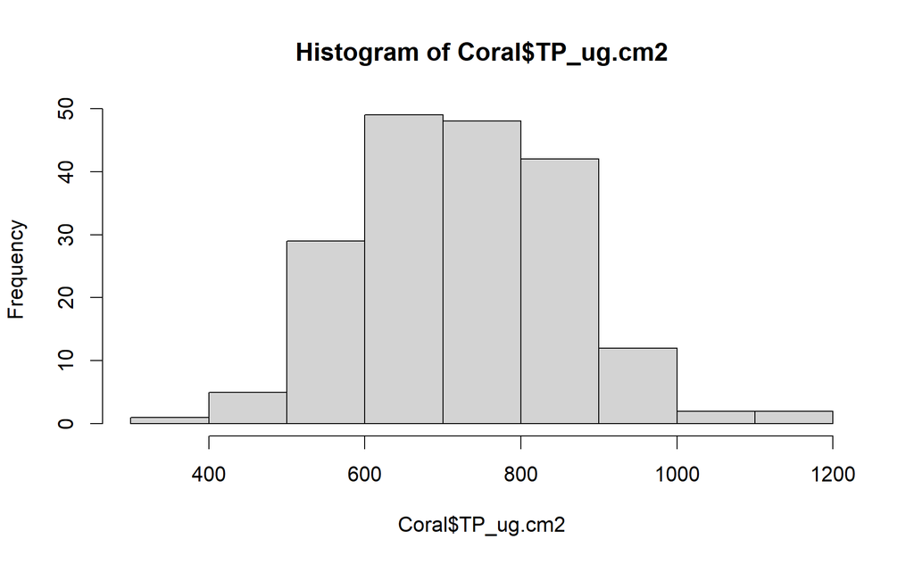

```r
##Check normality
hist(Coral$TP_ug.cm2)
```

```r
shapiro.test(Coral$TP_ug.cm2)
```

```
    Shapiro-Wilk normality test

data:  Coral$TP_ug.cm2
W = 0.99598, p-value = 0.899
```

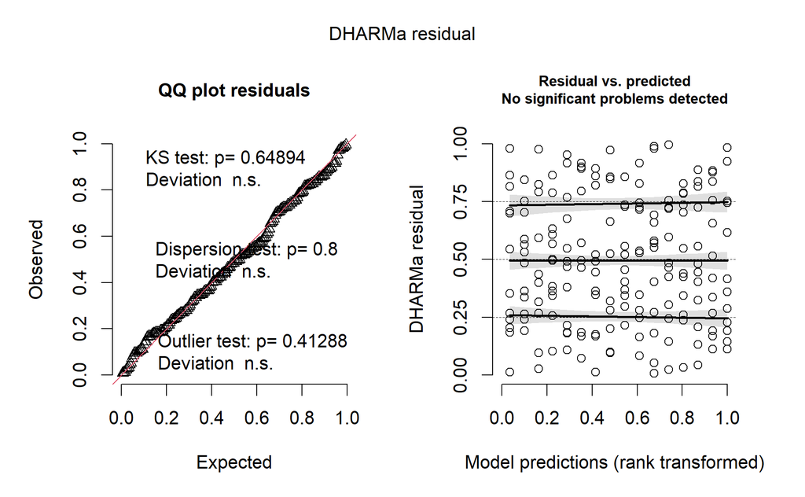

```r
#Normal

##Model
#Function of Site and Origin and Time, with Genotype as a Random effect
#All interactions included
Prot.lme<-lmer(TP_ug.cm2~Origin*Site*TimeP+(1|Genotype), data=Coral)

##Check residuals
Prot.lme_res <- simulateResiduals(fittedModel = Prot.lme, plot = F)
plot(Prot.lme_res)
```

```r
##Model results
anova(Prot.lme)
```

```
Type III Analysis of Variance Table with Satterthwaite's method
                  Sum Sq Mean Sq NumDF  DenDF F value    Pr(>F)
Origin             40878   40878     1 172.01  3.7211   0.05538 .
Site              340873  340873     1 172.00 31.0292 9.637e-08 ***
TimeP             641897  213966     3 172.01 19.4770 6.422e-11 ***
Origin:Site         8746    8746     1 172.00  0.7961   0.37350
Origin:TimeP       14295    4765     3 172.01  0.4337   0.72911
Site:TimeP         36271   12090     3 172.00  1.1006   0.35045
Origin:Site:TimeP  64823   21608     3 172.00  1.9669   0.12078
---
Signif. codes:  0 ‘***’ 0.001 ‘**’ 0.01 ‘*’ 0.05 ‘.’ 0.1 ‘ ’ 1
```

```r
eta_squared(Prot.lme)
```

```
# Effect Size for ANOVA (Type III)

Parameter         | Eta2 (partial) |       95% CI
-------------------------------------------------
Origin            |           0.02 | [0.00, 1.00]
Site              |           0.15 | [0.08, 1.00]
TimeP             |           0.25 | [0.16, 1.00]
Origin:Site       |       4.61e-03 | [0.00, 1.00]
Origin:TimeP      |       7.51e-03 | [0.00, 1.00]
Site:TimeP        |           0.02 | [0.00, 1.00]
Origin:Site:TimeP |           0.03 | [0.00, 1.00]

- One-sided CIs: upper bound fixed at [1.00].
```

```r
##Save model results
Prot.res<-data.frame(anova(Prot.lme))
Prot.res$Predictor<-c("Origin", "Site", "Time", "Origin x Site", "Origin x Time", "Site x Time", "Origin x Site x Time")
Prot.res$EtaSq<-c(eta_squared(Prot.lme)$Eta2)
Prot.res$Response<-rep("Protein", nrow(Prot.res))
```

#### Pairwise

```r
##Pairwise Comparisons of Interest
#Native vs Transplant within a Site and Timepoint
Prot.pair<-emmeans(Prot.lme, pairwise~Origin | Site*TimeP)
Prot.pair
```

```
$emmeans
Site = KL, TimeP = TP1:
 Origin     emmean SE   df lower.CL upper.CL
 Native        800 43 6.90      698      902
 Transplant    804 43 6.90      702      906

Site = SS, TimeP = TP1:
 Origin     emmean SE   df lower.CL upper.CL
 Native        897 43 6.90      795      999
 Transplant    784 43 6.90      682      886

Site = KL, TimeP = TP2:
 Origin     emmean SE   df lower.CL upper.CL
 Native        645 43 6.90      543      747
 Transplant    613 43 6.90      512      715

Site = SS, TimeP = TP2:
 Origin     emmean SE   df lower.CL upper.CL
 Native        730 43 6.90      628      832
 Transplant    743 43 6.90      641      845

Site = KL, TimeP = TP3:
 Origin     emmean SE   df lower.CL upper.CL
 Native        705 43 6.90      603      807
 Transplant    645 43 6.90      543      747

Site = SS, TimeP = TP3:
 Origin     emmean SE   df lower.CL upper.CL
 Native        770 43 6.90      668      872
 Transplant    758 43 6.90      656      860

Site = KL, TimeP = TP4:
 Origin     emmean SE   df lower.CL upper.CL
 Native        612 43 6.90      510      714
 Transplant    636 44 7.53      533      738

Site = SS, TimeP = TP4:
 Origin     emmean SE   df lower.CL upper.CL
 Native        757 43 6.90      655      859
 Transplant    699 44 7.53      596      801
```

[output cut: 23 more lines]

```
 Native - Transplant    59.41 42.8 172   1.388  0.1668

Site = SS, TimeP = TP3:
 contrast            estimate   SE  df t.ratio p.value
 Native - Transplant    12.29 42.8 172   0.287  0.7743

Site = KL, TimeP = TP4:
 contrast            estimate   SE  df t.ratio p.value
 Native - Transplant   -23.18 43.8 172  -0.530  0.5970

Site = SS, TimeP = TP4:
 contrast            estimate   SE  df t.ratio p.value
 Native - Transplant    58.42 43.8 172   1.335  0.1836

Degrees-of-freedom method: kenward-roger
```

```r
#Calculate standardized effect sizes for pairwise comparisons
Prot.pair.es<-data.frame(eff_size(Prot.pair, sigma=sigma(Prot.lme), edf=df.residual(Prot.lme)))
```

```
Since 'object' is a list, we are using the contrasts already present.
```

```r
Prot.pair.es
```

|  | contrast | Site | TimeP | effect.size | SE | df | lower.CL | upper.CL |
| --- | --- | --- | --- | --- | --- | --- | --- | --- |
| 1 | (Native - Transplant) | KL | TP1 | -0.04350894 | 0.4082550 | 172.0000 | -0.8493440 | 0.7623261 |
| 2 | (Native - Transplant) | SS | TP1 | 1.08103268 | 0.4123880 | 172.0000 | 0.2670398 | 1.8950256 |
| 3 | (Native - Transplant) | KL | TP2 | 0.29996391 | 0.4085685 | 172.0000 | -0.5064899 | 1.1064178 |
| 4 | (Native - Transplant) | SS | TP2 | -0.11747540 | 0.4082974 | 172.0000 | -0.9233942 | 0.6884433 |
| 5 | (Native - Transplant) | KL | TP3 | 0.56680658 | 0.4093905 | 172.0000 | -0.2412698 | 1.3748829 |
| 6 | (Native - Transplant) | SS | TP3 | 0.11724297 | 0.4082972 | 172.0000 | -0.6886754 | 0.9231613 |
| 7 | (Native - Transplant) | KL | TP4 | -0.22116794 | 0.4177057 | 172.0102 | -1.0456568 | 0.6033209 |
| 8 | (Native - Transplant) | SS | TP4 | 0.55742377 | 0.4186157 | 172.0102 | -0.2688613 | 1.3837089 |

```r
Prot.pair.es<-Prot.pair.es %>% dplyr::rename(contrast.se = contrast, SE.es = SE, df.es = df)


##Save Results
Prot.pair.res<-merge(data.frame(Prot.pair$contrasts), Prot.pair.es[,-c(1)])
Prot.pair.res$Response<-rep("Protein", nrow(Prot.pair.res))
```

### Biomass

#### Model

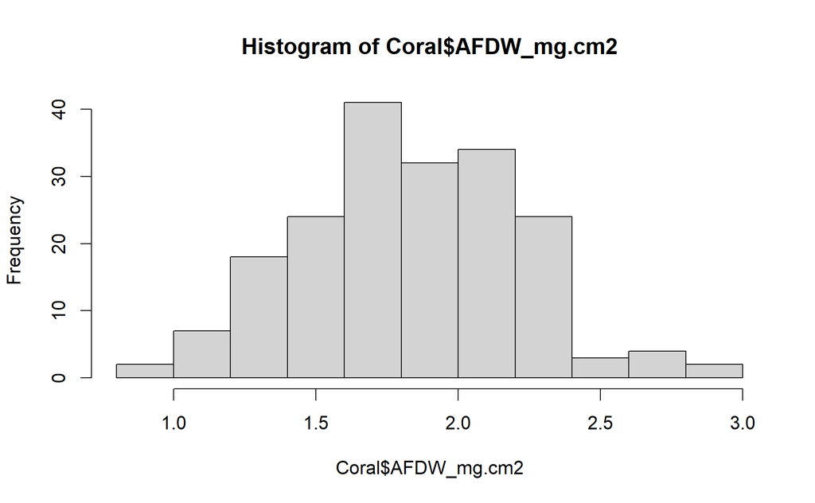

```r
##Check normality
hist(Coral$AFDW_mg.cm2)
```

```r
shapiro.test(Coral$AFDW_mg.cm2)
```

```
    Shapiro-Wilk normality test

data:  Coral$AFDW_mg.cm2
W = 0.99471, p-value = 0.738
```

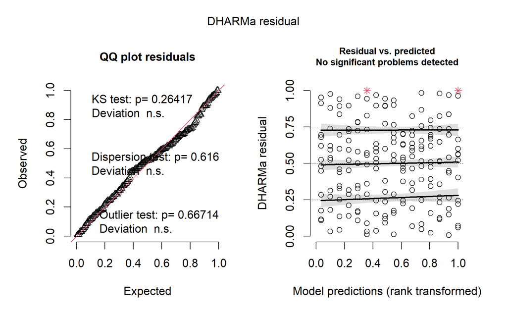

```r
#Normal

##Model
#Function of Site and Origin and Time, with Genotype as a Random effect
#All Interactions included
Bio.lme<-lmer(AFDW_mg.cm2~Origin*Site*TimeP+(1|Genotype), data=Coral)

##Check residuals
Bio.lme_res <- simulateResiduals(fittedModel = Bio.lme, plot = F)
plot(Bio.lme_res)
```

```r
##Model results
anova(Bio.lme)
```

```
Type III Analysis of Variance Table with Satterthwaite's method
                   Sum Sq Mean Sq NumDF DenDF F value    Pr(>F)
Origin            0.54363 0.54363     1   173  4.8892   0.02834 *
Site              2.40287 2.40287     1   173 21.6104 6.602e-06 ***
TimeP             1.22345 0.40782     3   173  3.6677   0.01348 *
Origin:Site       0.00011 0.00011     1   173  0.0010   0.97483
Origin:TimeP      0.39777 0.13259     3   173  1.1925   0.31420
Site:TimeP        0.53215 0.17738     3   173  1.5953   0.19230
Origin:Site:TimeP 1.05035 0.35012     3   173  3.1488   0.02646 *
---
Signif. codes:  0 ‘***’ 0.001 ‘**’ 0.01 ‘*’ 0.05 ‘.’ 0.1 ‘ ’ 1
```

```r
eta_squared(Bio.lme)
```

```
# Effect Size for ANOVA (Type III)

Parameter         | Eta2 (partial) |       95% CI
-------------------------------------------------
Origin            |           0.03 | [0.00, 1.00]
Site              |           0.11 | [0.05, 1.00]
TimeP             |           0.06 | [0.01, 1.00]
Origin:Site       |       5.77e-06 | [0.00, 1.00]
Origin:TimeP      |           0.02 | [0.00, 1.00]
Site:TimeP        |           0.03 | [0.00, 1.00]
Origin:Site:TimeP |           0.05 | [0.00, 1.00]

- One-sided CIs: upper bound fixed at [1.00].
```

```r
##Save model results
Bio.res<-data.frame(anova(Bio.lme))
Bio.res$Predictor<-c("Origin", "Site", "Time", "Origin x Site", "Origin x Time", "Site x Time", "Origin x Site x Time")
Bio.res$EtaSq<-c(eta_squared(Bio.lme)$Eta2)
Bio.res$Response<-rep("Biomass", nrow(Bio.res))
```

#### Pairwise

```r
##Pairwise Comparisons of Interest
#Native vs Transplant within a Site and Timepoint
Bio.pair<-emmeans(Bio.lme, pairwise~Origin | Site*TimeP)
Bio.pair
```

```
$emmeans
Site = KL, TimeP = TP1:
 Origin     emmean    SE   df lower.CL upper.CL
 Native       1.78 0.118 13.7     1.52     2.03
 Transplant   1.60 0.118 13.7     1.35     1.86

Site = SS, TimeP = TP1:
 Origin     emmean    SE   df lower.CL upper.CL
 Native       1.93 0.118 13.7     1.67     2.18
 Transplant   1.57 0.118 13.7     1.32     1.83

Site = KL, TimeP = TP2:
 Origin     emmean    SE   df lower.CL upper.CL
 Native       1.88 0.118 13.7     1.63     2.13
 Transplant   1.66 0.118 13.7     1.40     1.91

Site = SS, TimeP = TP2:
 Origin     emmean    SE   df lower.CL upper.CL
 Native       1.90 0.118 13.7     1.64     2.15
 Transplant   2.04 0.118 13.7     1.79     2.30

Site = KL, TimeP = TP3:
 Origin     emmean    SE   df lower.CL upper.CL
 Native       1.85 0.118 13.7     1.60     2.11
 Transplant   1.69 0.118 13.7     1.44     1.94

Site = SS, TimeP = TP3:
 Origin     emmean    SE   df lower.CL upper.CL
 Native       2.08 0.118 13.7     1.83     2.33
 Transplant   2.11 0.118 13.7     1.86     2.37

Site = KL, TimeP = TP4:
 Origin     emmean    SE   df lower.CL upper.CL
 Native       1.58 0.118 13.7     1.33     1.84
 Transplant   1.71 0.118 13.7     1.46     1.97

Site = SS, TimeP = TP4:
 Origin     emmean    SE   df lower.CL upper.CL
 Native       2.08 0.118 13.7     1.83     2.34
 Transplant   1.83 0.122 15.3     1.57     2.09
```

[output cut: 23 more lines]

```
 Native - Transplant   0.1650 0.136 173   1.212  0.2273

Site = SS, TimeP = TP3:
 contrast            estimate    SE  df t.ratio p.value
 Native - Transplant  -0.0342 0.136 173  -0.252  0.8017

Site = KL, TimeP = TP4:
 contrast            estimate    SE  df t.ratio p.value
 Native - Transplant  -0.1290 0.136 173  -0.948  0.3445

Site = SS, TimeP = TP4:
 contrast            estimate    SE  df t.ratio p.value
 Native - Transplant   0.2516 0.139 173   1.807  0.0725

Degrees-of-freedom method: kenward-roger
```

```r
#Calculate standardized effect sizes for pairwise comparisons
Bio.pair.es<-data.frame(eff_size(Bio.pair, sigma=sigma(Bio.lme), edf=df.residual(Bio.lme)))
```

```
Since 'object' is a list, we are using the contrasts already present.
```

```r
Bio.pair.es
```

|  | contrast | Site | TimeP | effect.size | SE | df | lower.CL | upper.CL |
| --- | --- | --- | --- | --- | --- | --- | --- | --- |
| 1 | (Native - Transplant) | KL | TP1 | 0.5242139 | 0.4092199 | 173.0000 | -0.28349253 | 1.3319203 |
| 2 | (Native - Transplant) | SS | TP1 | 1.0554954 | 0.4121729 | 173.0000 | 0.24196030 | 1.8690305 |
| 3 | (Native - Transplant) | KL | TP2 | 0.6666344 | 0.4098183 | 173.0000 | -0.14225328 | 1.4755221 |
| 4 | (Native - Transplant) | SS | TP2 | -0.4454427 | 0.4089500 | 173.0000 | -1.25261659 | 0.3617311 |
| 5 | (Native - Transplant) | KL | TP3 | 0.4946873 | 0.4091136 | 173.0000 | -0.31280936 | 1.3021840 |
| 6 | (Native - Transplant) | SS | TP3 | -0.1026826 | 0.4082856 | 173.0000 | -0.90854502 | 0.7031799 |
| 7 | (Native - Transplant) | KL | TP4 | -0.3869689 | 0.4087780 | 173.0000 | -1.19380323 | 0.4198654 |
| 8 | (Native - Transplant) | SS | TP4 | 0.7546060 | 0.4195059 | 173.0193 | -0.07340207 | 1.5826140 |

```r
Bio.pair.es<-Bio.pair.es %>% dplyr::rename(contrast.se = contrast, SE.es = SE, df.es = df)

##Save Results
Bio.pair.res<-merge(data.frame(Bio.pair$contrasts), Bio.pair.es[,-c(1)])
Bio.pair.res$Response<-rep("Biomass", nrow(Bio.pair.res))
```

### Chlorophyll

#### Model

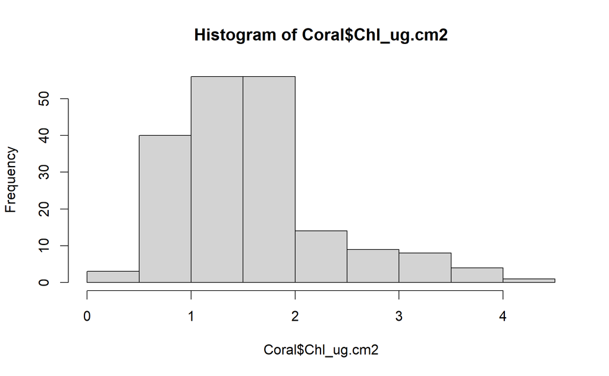

```r
##Check normality
hist(Coral$Chl_ug.cm2)
```

```r
shapiro.test(Coral$Chl_ug.cm2)
```

```
    Shapiro-Wilk normality test

data:  Coral$Chl_ug.cm2
W = 0.90772, p-value = 1.539e-09
```

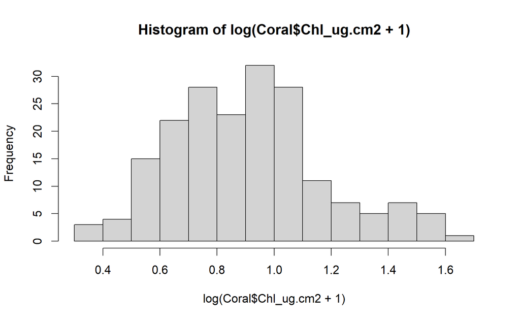

```r
#Not normal

hist(log(Coral$Chl_ug.cm2+1))
```

```r
shapiro.test(log(Coral$Chl_ug.cm2+1))
```

```
    Shapiro-Wilk normality test

data:  log(Coral$Chl_ug.cm2 + 1)
W = 0.9739, p-value = 0.001228
```

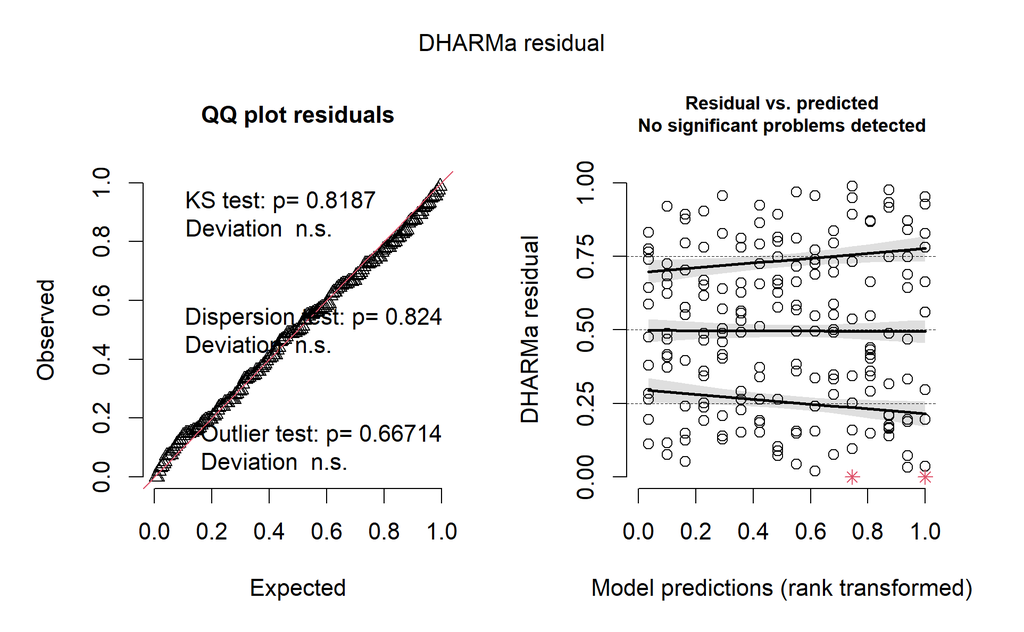

```r
#Improved

##Model
#Function of Site and Origin and Time, with Genotype as a Random effect
#All Interactions included
Chl.lme<-lmer(log(Chl_ug.cm2+1)~Origin*Site*TimeP+(1|Genotype), data=Coral)

##Check residuals
Chl.lme_res <- simulateResiduals(fittedModel = Chl.lme, plot = F)
plot(Chl.lme_res)
```

```r
##Model results
anova(Chl.lme)
```

```
Type III Analysis of Variance Table with Satterthwaite's method
                  Sum Sq Mean Sq NumDF DenDF  F value    Pr(>F)
Origin            0.0281  0.0281     1   173   1.6636 0.1988431
Site              3.5678  3.5678     1   173 210.8556 < 2.2e-16 ***
TimeP             4.0354  1.3451     3   173  79.4961 < 2.2e-16 ***
Origin:Site       0.0365  0.0365     1   173   2.1546 0.1439635
Origin:TimeP      0.0523  0.0174     3   173   1.0297 0.3808371
Site:TimeP        0.3817  0.1272     3   173   7.5199 9.271e-05 ***
Origin:Site:TimeP 0.3489  0.1163     3   173   6.8730 0.0002118 ***
---
Signif. codes:  0 ‘***’ 0.001 ‘**’ 0.01 ‘*’ 0.05 ‘.’ 0.1 ‘ ’ 1
```

```r
eta_squared(Chl.lme)
```

```
# Effect Size for ANOVA (Type III)

Parameter         | Eta2 (partial) |       95% CI
-------------------------------------------------
Origin            |       9.52e-03 | [0.00, 1.00]
Site              |           0.55 | [0.47, 1.00]
TimeP             |           0.58 | [0.50, 1.00]
Origin:Site       |           0.01 | [0.00, 1.00]
Origin:TimeP      |           0.02 | [0.00, 1.00]
Site:TimeP        |           0.12 | [0.04, 1.00]
Origin:Site:TimeP |           0.11 | [0.04, 1.00]

- One-sided CIs: upper bound fixed at [1.00].
```

```r
##Save model results
Chl.res<-data.frame(anova(Chl.lme))
Chl.res$Predictor<-c("Origin", "Site", "Time", "Origin x Site", "Origin x Time", "Site x Time", "Origin x Site x Time")
Chl.res$EtaSq<-c(eta_squared(Chl.lme)$Eta2)
Chl.res$Response<-rep("Chlorophyll", nrow(Chl.res))
```

#### Pairwise

```r
##Pairwise Comparisons of Interest
#Native vs Transplant within a Site and Timepoint
Chl.pair<-emmeans(Chl.lme, pairwise~Origin | Site*TimeP)
Chl.pair
```

```
$emmeans
Site = KL, TimeP = TP1:
 Origin     emmean     SE   df lower.CL upper.CL
 Native      0.613 0.0834 3.05    0.351    0.876
 Transplant  0.651 0.0834 3.05    0.388    0.914

Site = SS, TimeP = TP1:
 Origin     emmean     SE   df lower.CL upper.CL
 Native      0.863 0.0834 3.05    0.600    1.126
 Transplant  0.679 0.0834 3.05    0.416    0.942

Site = KL, TimeP = TP2:
 Origin     emmean     SE   df lower.CL upper.CL
 Native      0.820 0.0834 3.05    0.557    1.083
 Transplant  0.704 0.0834 3.05    0.441    0.967

Site = SS, TimeP = TP2:
 Origin     emmean     SE   df lower.CL upper.CL
 Native      1.037 0.0834 3.05    0.774    1.300
 Transplant  1.158 0.0834 3.05    0.895    1.421

Site = KL, TimeP = TP3:
 Origin     emmean     SE   df lower.CL upper.CL
 Native      0.820 0.0834 3.05    0.557    1.083
 Transplant  0.715 0.0834 3.05    0.452    0.978

Site = SS, TimeP = TP3:
 Origin     emmean     SE   df lower.CL upper.CL
 Native      1.000 0.0834 3.05    0.737    1.263
 Transplant  1.032 0.0834 3.05    0.769    1.295

Site = KL, TimeP = TP4:
 Origin     emmean     SE   df lower.CL upper.CL
 Native      0.940 0.0834 3.05    0.677    1.203
 Transplant  0.914 0.0834 3.05    0.651    1.177

Site = SS, TimeP = TP4:
 Origin     emmean     SE   df lower.CL upper.CL
 Native      1.276 0.0834 3.05    1.013    1.538
 Transplant  1.320 0.0841 3.16    1.060    1.580
```

[output cut: 25 more lines]

```

Site = SS, TimeP = TP3:
 contrast            estimate     SE  df t.ratio p.value
 Native - Transplant  -0.0319 0.0531 173  -0.600  0.5490

Site = KL, TimeP = TP4:
 contrast            estimate     SE  df t.ratio p.value
 Native - Transplant   0.0255 0.0531 173   0.479  0.6323

Site = SS, TimeP = TP4:
 contrast            estimate     SE  df t.ratio p.value
 Native - Transplant  -0.0446 0.0543 173  -0.821  0.4128

Note: contrasts are still on the log(mu + 1) scale
Degrees-of-freedom method: kenward-roger
```

```r
#Calculate standardized effect sizes for pairwise comparisons
Chl.pair.es<-data.frame(eff_size(Chl.pair, sigma=sigma(Chl.lme), edf=df.residual(Chl.lme)))
```

```
Since 'object' is a list, we are using the contrasts already present.
```

```r
Chl.pair.es
```

|  | contrast | Site | TimeP | effect.size | SE | df | lower.CL | upper.CL |
| --- | --- | --- | --- | --- | --- | --- | --- | --- |
| 1 | (Native - Transplant) | KL | TP1 | -0.2918755 | 0.4085497 | 173.0003 | -1.098259241 | 0.5145082 |
| 2 | (Native - Transplant) | SS | TP1 | 1.4128045 | 0.4152535 | 173.0003 | 0.593188961 | 2.2324200 |
| 3 | (Native - Transplant) | KL | TP2 | 0.8875622 | 0.4110273 | 173.0003 | 0.076288314 | 1.6988361 |
| 4 | (Native - Transplant) | SS | TP2 | -0.9280180 | 0.4112855 | 173.0003 | -1.739801419 | -0.1162345 |
| 5 | (Native - Transplant) | KL | TP3 | 0.8053293 | 0.4105376 | 173.0003 | -0.004977957 | 1.6156366 |
| 6 | (Native - Transplant) | SS | TP3 | -0.2451240 | 0.4084609 | 173.0003 | -1.051332466 | 0.5610844 |
| 7 | (Native - Transplant) | KL | TP4 | 0.1956733 | 0.4083838 | 173.0003 | -0.610382921 | 1.0017295 |
| 8 | (Native - Transplant) | SS | TP4 | -0.3427510 | 0.4179359 | 173.0003 | -1.167661004 | 0.4821589 |

```r
Chl.pair.es<-Chl.pair.es %>% dplyr::rename(contrast.se = contrast, SE.es = SE, df.es = df)

##Save Results
Chl.pair.res<-merge(data.frame(Chl.pair$contrasts), Chl.pair.es[,-c(1)])
Chl.pair.res$Response<-rep("Chlorophyll", nrow(Chl.pair.res))
```

### Save Results

```r
##Combine Results
Phys.res<-rbind(Prot.res, Bio.res, Chl.res)

##Add Timepoint
Phys.res$TimeP<-rep("All", nrow(Phys.res))
```

### Native v Transplant Effect Sizes

```r
##Combine Pairwise Results
Phys.pair.res<-rbind(Prot.pair.res, Bio.pair.res, Chl.pair.res)

##Add Significance levels
Phys.pair.res$Sig<-ifelse(Phys.pair.res$p.value<0.001, "***", ifelse(Phys.pair.res$p.value<0.01, "**",
            ifelse(Phys.pair.res$p.value<0.05, "*", ifelse(Phys.pair.res$p.value<0.1, "-", NA))))

Phys.pair.res$Significant<-ifelse(Phys.pair.res$p.value<0.05, "sig", "non")

##Set Order
Phys.pair.res$Response<-factor(Phys.pair.res$Response, levels=c("Biomass", "Protein", "Chlorophyll"), ordered=TRUE)
```

#### Plot Effect Size of Origin

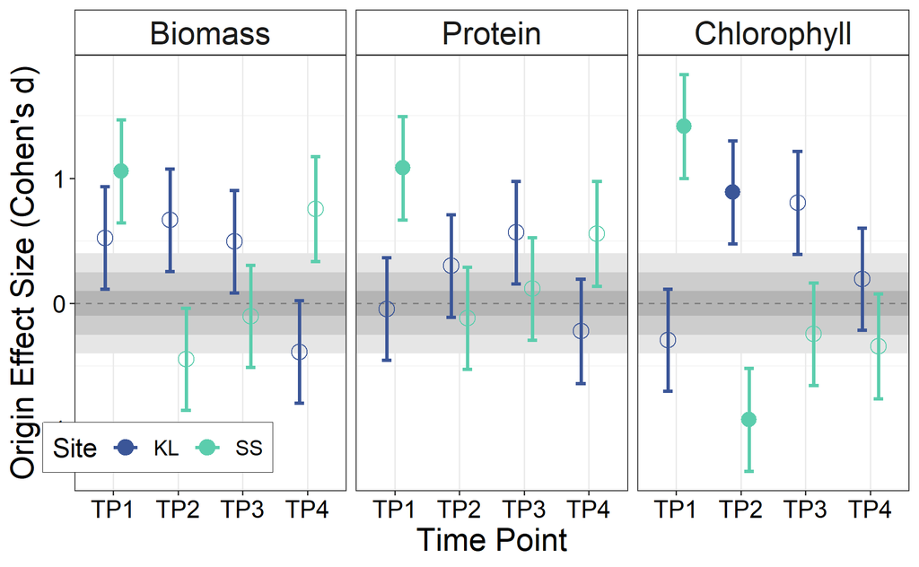

```r
##Plot Effect Size across Timepoints
Phys.Orig.ES.plot<-ggplot(Phys.pair.res, aes(x=TimeP, y=effect.size)) +
  geom_rect(fill="grey90", alpha=0.4, xmin=-Inf, xmax=Inf, ymin=-.4, ymax=0.4)+
  geom_rect(fill="grey80", alpha=0.4, xmin=-Inf, xmax=Inf, ymin=-.25, ymax=0.25)+
  geom_rect(fill="grey70", alpha=0.4, xmin=-Inf, xmax=Inf, ymin=-.1, ymax=0.1)+
  geom_hline(yintercept=0, linetype="dashed", color="grey50", linewidth=0.5)+
  geom_errorbar(aes(ymin=effect.size-SE.es, ymax=effect.size+SE.es, colour=Site), width=cap.sz, linewidth=bar.sz, position=position_dodge(width=0.5)) +
  geom_point(aes(shape=Significant, colour=Site), size=point.sz, position=position_dodge(width=0.5))+
  facet_wrap(vars(Response))+
  scale_colour_manual(values=Site.colors.o)+
  scale_shape_manual(values=c(1, 16))+
  theme_bw()+
  theme(axis.title.x = element_text(size = axis.title.sz),
        axis.title.y = element_text(size = axis.title.sz),
        axis.text.x=element_text(size=axis.txt.sz, colour="black"),
        axis.text.y=element_text(size=axis.txt.sz, colour="black"),
        legend.text=element_text(size=leg.txt.sz),
        legend.title=element_text(size=leg.title.sz),
        legend.box.background = element_rect(color = "black"),
        legend.position=c(.1, .1),
        legend.direction = "horizontal",
        strip.text=element_text(size=axis.title.sz),
        strip.background = element_rect(fill="white"),
        panel.grid.major.y=element_blank())+
  labs(x="Time Point", y="Origin Effect Size (Cohen's d)", colour="Site")+
  guides(shape="none"); Phys.Orig.ES.plot
```

# Univariate by Timepoint

Given the interactions with Time, model each timepoint separately to compare the effect of Origin or current Site. Using partial Eta Squared as effect size within models with interactions.

### TP1

```r
##Subset Timepoint 1
Coral.TP1<-subset(Coral, TimeP=="TP1")
```

#### Protein

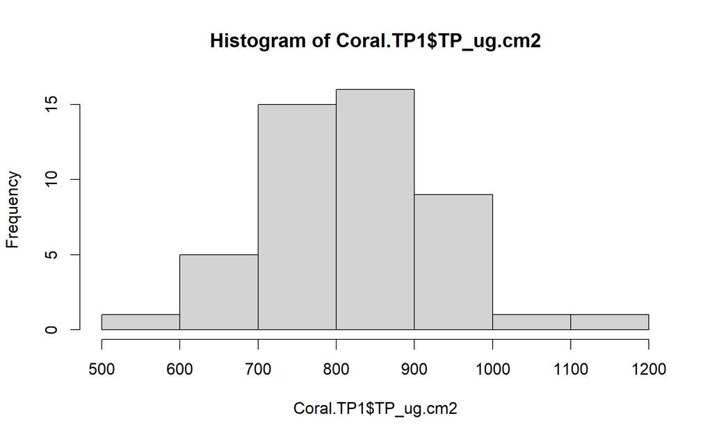

```r
##Check normality
hist(Coral.TP1$TP_ug.cm2)
```

```r
shapiro.test(Coral.TP1$TP_ug.cm2)
```

```
    Shapiro-Wilk normality test

data:  Coral.TP1$TP_ug.cm2
W = 0.99032, p-value = 0.9593
```

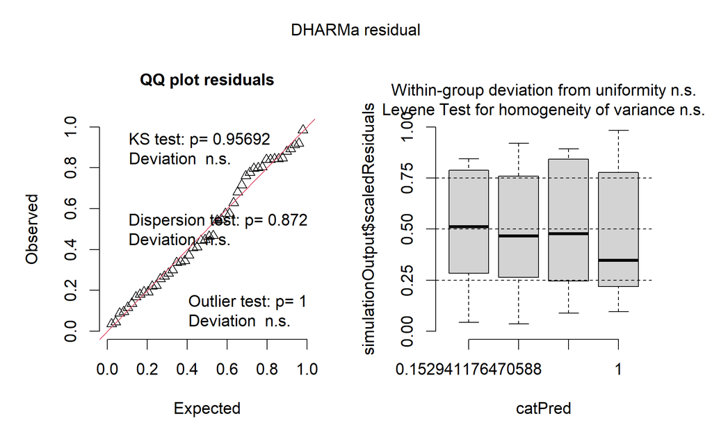

```r
#Normal

##Model
#Function of Site and Origin, with Genotype as a Random effect
#Interactions between Origin and Site
Prot.lme_TP1<-lmer(TP_ug.cm2~Origin*Site+(1|Genotype), data=Coral.TP1)

##Check residuals
Prot.lme_res_TP1 <- simulateResiduals(fittedModel = Prot.lme_TP1, plot = F)
plot(Prot.lme_res_TP1)
```

```r
##Model results
summary(Prot.lme_TP1)
```

```
Linear mixed model fit by REML. t-tests use Satterthwaite's method ['lmerModLmerTest']
Formula: TP_ug.cm2 ~ Origin * Site + (1 | Genotype)
   Data: Coral.TP1

REML criterion at convergence: 531.8

Scaled residuals:
    Min      1Q  Median      3Q     Max
-1.8591 -0.7101 -0.0471  0.5560  1.9978

Random effects:
 Groups   Name        Variance Std.Dev.
 Genotype (Intercept) 5539     74.42
 Residual             7375     85.88
Number of obs: 48, groups:  Genotype, 3

Fixed effects:
                        Estimate Std. Error       df t value Pr(>|t|)
(Intercept)              799.728     49.607    3.021  16.121 0.000499 ***
OriginTransplant           4.560     35.060   42.000   0.130 0.897131
SiteSS                    97.406     35.060   42.000   2.778 0.008136 **
OriginTransplant:SiteSS -117.865     49.582   42.000  -2.377 0.022077 *
---
Signif. codes:  0 ‘***’ 0.001 ‘**’ 0.01 ‘*’ 0.05 ‘.’ 0.1 ‘ ’ 1

Correlation of Fixed Effects:
            (Intr) OrgnTr SiteSS
OrgnTrnspln -0.353
SiteSS      -0.353  0.500
OrgnTrn:SSS  0.250 -0.707 -0.707
```

```r
eta_squared(Prot.lme_TP1)
```

```
# Effect Size for ANOVA (Type III)

Parameter   | Eta2 (partial) |       95% CI
-------------------------------------------
Origin      |           0.10 | [0.00, 1.00]
Site        |           0.05 | [0.00, 1.00]
Origin:Site |           0.12 | [0.01, 1.00]

- One-sided CIs: upper bound fixed at [1.00].
```

```r
##Save model results
Prot_TP1.res<-data.frame(summary(Prot.lme_TP1)$coefficients[-1,])
Prot_TP1.res$Predictor<-c("Origin", "Site", "Origin x Site")
Prot_TP1.res$EtaSq<-c(eta_squared(Prot.lme_TP1)$Eta2)
Prot_TP1.res$Response<-rep("Protein", nrow(Prot_TP1.res))
```

```r
##Pairwise Comparisons of Interest
#Native vs Transplant within a Site
Prot.pair_TP1<-emmeans(Prot.lme_TP1, pairwise~Origin | Site)
Prot.pair_TP1
```

```
$emmeans
Site = KL:
 Origin     emmean   SE   df lower.CL upper.CL
 Native        800 49.6 3.02      642      957
 Transplant    804 49.6 3.02      647      962

Site = SS:
 Origin     emmean   SE   df lower.CL upper.CL
 Native        897 49.6 3.02      740     1054
 Transplant    784 49.6 3.02      627      941

Degrees-of-freedom method: kenward-roger
Confidence level used: 0.95

$contrasts
Site = KL:
 contrast            estimate   SE df t.ratio p.value
 Native - Transplant    -4.56 35.1 42  -0.130  0.8971

Site = SS:
 contrast            estimate   SE df t.ratio p.value
 Native - Transplant   113.31 35.1 42   3.232  0.0024

Degrees-of-freedom method: kenward-roger
```

```r
#Calculate standardized effect sizes for pairwise comparisons
Prot.pair.es_TP1<-data.frame(eff_size(Prot.pair_TP1, sigma=sigma(Prot.lme_TP1), edf=df.residual(Prot.lme_TP1)))
```

```
Since 'object' is a list, we are using the contrasts already present.
```

```r
Prot.pair.es_TP1
```

|  | contrast | Site | effect.size | SE | df | lower.CL | upper.CL |
| --- | --- | --- | --- | --- | --- | --- | --- |
| 1 | (Native - Transplant) | KL | -0.05310115 | 0.4082894 | 42 | -0.8770625 | 0.7708602 |
| 2 | (Native - Transplant) | SS | 1.31936291 | 0.4328851 | 42 | 0.4457654 | 2.1929604 |

```r
Prot.pair.es_TP1<-Prot.pair.es_TP1 %>% dplyr::rename(contrast.se = contrast, SE.es = SE, df.es = df)

##Save Results
Prot.pair_TP1.res<-merge(data.frame(Prot.pair_TP1$contrasts), Prot.pair.es_TP1[,-c(1)])
Prot.pair_TP1.res$Response<-rep("Protein", nrow(Prot.pair_TP1.res))

##Add Significance levels
Prot.pair_TP1.res$Sig<-ifelse(Prot.pair_TP1.res$p.value<0.001, "***",
                              ifelse(Prot.pair_TP1.res$p.value<0.01, "**",
                                     ifelse(Prot.pair_TP1.res$p.value<0.05, "*",
                                            ifelse(Prot.pair_TP1.res$p.value<0.1, "-", NA))))
Prot.pair_TP1.res
```

| Site | contrast | estimate | SE | df | t.ratio | p.value | effect.size | SE.es | df.es | lower.CL | upper.CL | Response | Sig |
| --- | --- | --- | --- | --- | --- | --- | --- | --- | --- | --- | --- | --- | --- |
| KL | Native - Transplant | -4.560256 | 35.05982 | 42 | -0.1300707 | 0.897131448 | -0.05310115 | 0.4082894 | 42 | -0.8770625 | 0.7708602 | Protein | NA |
| SS | Native - Transplant | 113.305131 | 35.05982 | 42 | 3.2317659 | 0.002394987 | 1.31936291 | 0.4328851 | 42 | 0.4457654 | 2.1929604 | Protein | ** |

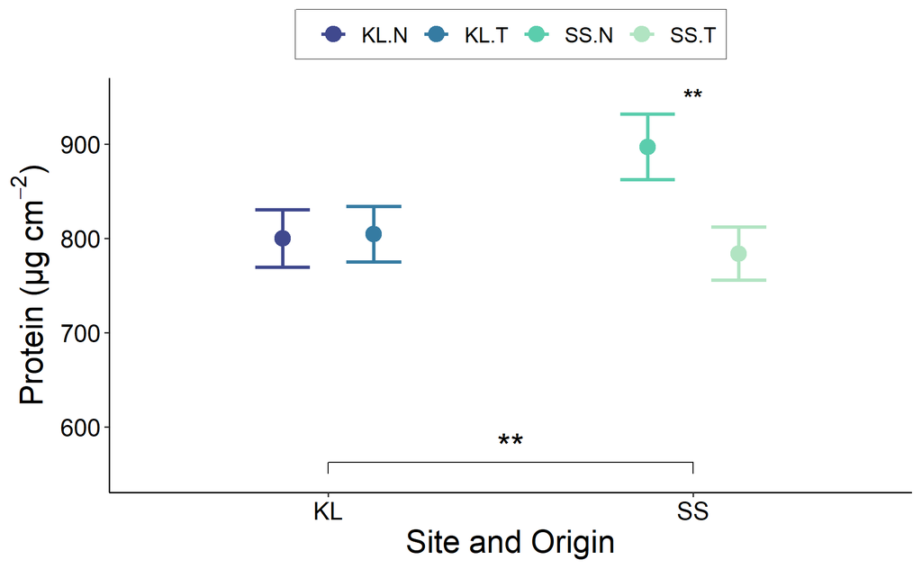

```r
##Summary statistics by Site and Origin
TP1_Prot.sum<-summarySE(Coral.TP1, measurevar="TP_ug.cm2", groupvars=c("Site", "Origin", "Site.Orig"), na.rm=TRUE)

##Plot Average Protein across Treatments
TP1_Prot.plot<-ggplot(TP1_Prot.sum, aes(x=Site, y=TP_ug.cm2, colour=Site.Orig)) +
  scale_colour_manual(values=Orig.colors.o)+
  geom_errorbar(aes(ymin=TP_ug.cm2-se, ymax=TP_ug.cm2+se), width=cap.sz, linewidth=bar.sz, position=position_dodge(width=0.5)) +
  geom_point(size=point.sz, position=position_dodge(width=0.5))+
  theme_classic()+
  theme(axis.title.x = element_text(size = axis.title.sz),
        axis.title.y = element_text(size = axis.title.sz),
        axis.text.x=element_text(size=axis.txt.sz, colour="black"),
        axis.text.y=element_text(size=axis.txt.sz, colour="black"),
        legend.text=element_text(size=leg.txt.sz),
        legend.title=element_text(size=leg.title.sz),
        legend.box.background = element_rect(color = "black"),
        legend.position="top")+
  labs(x="Site and Origin", y=expression(paste('Protein (\u03BCg cm'^-2*")")), colour=NULL)+
  ylim(550, 950)+
  annotate("text", x=2, y=950, label="**", size=sig.sz, fontface="bold")+
  geom_bracket(xmin=1, xmax=2, y.position=562, label.size=levels.sz, label="**", inherit.aes = FALSE); TP1_Prot.plot
```

#### Biomass

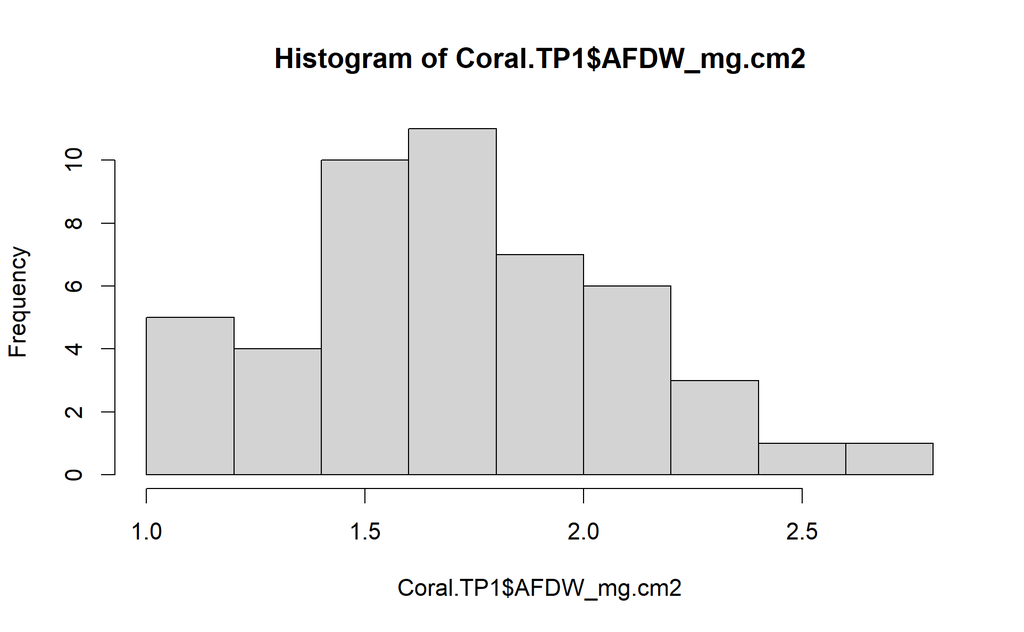

```r
##Check normality
hist(Coral.TP1$AFDW_mg.cm2)
```

```r
shapiro.test(Coral.TP1$AFDW_mg.cm2)
```

```
    Shapiro-Wilk normality test

data:  Coral.TP1$AFDW_mg.cm2
W = 0.9861, p-value = 0.8348
```

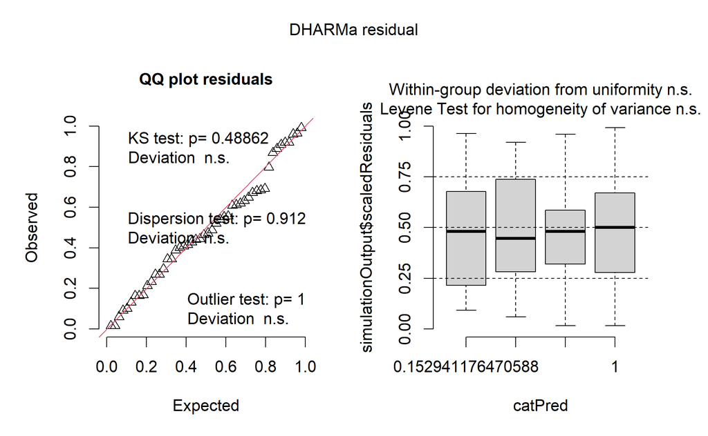

```r
#Normal

##Model
#Function of Site and Origin, with Genotype as a Random effect
#Interactions between Origin and Site
Bio.lme_TP1<-lmer(AFDW_mg.cm2~Origin*Site+(1|Genotype), data=Coral.TP1)

##Check residuals
Bio.lme_res_TP1 <- simulateResiduals(fittedModel = Bio.lme_TP1, plot = F)
plot(Bio.lme_res_TP1)
```

```r
##Model results
summary(Bio.lme_TP1)
```

```
Linear mixed model fit by REML. t-tests use Satterthwaite's method ['lmerModLmerTest']
Formula: AFDW_mg.cm2 ~ Origin * Site + (1 | Genotype)
   Data: Coral.TP1

REML criterion at convergence: 39

Scaled residuals:
     Min       1Q   Median       3Q      Max
-1.97569 -0.50353  0.01926  0.59699  2.04539

Random effects:
 Groups   Name        Variance Std.Dev.
 Genotype (Intercept) 0.0209   0.1446
 Residual             0.1062   0.3260
Number of obs: 48, groups:  Genotype, 3

Fixed effects:
                        Estimate Std. Error      df t value Pr(>|t|)
(Intercept)               1.7764     0.1258  5.7954  14.123 1.04e-05 ***
OriginTransplant         -0.1748     0.1331 42.0000  -1.314    0.196
SiteSS                    0.1494     0.1331 42.0000   1.123    0.268
OriginTransplant:SiteSS  -0.1772     0.1882 42.0000  -0.941    0.352
---
Signif. codes:  0 ‘***’ 0.001 ‘**’ 0.01 ‘*’ 0.05 ‘.’ 0.1 ‘ ’ 1

Correlation of Fixed Effects:
            (Intr) OrgnTr SiteSS
OrgnTrnspln -0.529
SiteSS      -0.529  0.500
OrgnTrn:SSS  0.374 -0.707 -0.707
```

```r
eta_squared(Bio.lme_TP1)
```

```
# Effect Size for ANOVA (Type III)

Parameter   | Eta2 (partial) |       95% CI
-------------------------------------------
Origin      |           0.16 | [0.03, 1.00]
Site        |       9.86e-03 | [0.00, 1.00]
Origin:Site |           0.02 | [0.00, 1.00]

- One-sided CIs: upper bound fixed at [1.00].
```

```r
##Save model results
Bio_TP1.res<-data.frame(summary(Bio.lme_TP1)$coefficients[-1,])
Bio_TP1.res$Predictor<-c("Origin", "Site", "Origin x Site")
Bio_TP1.res$EtaSq<-c(eta_squared(Bio.lme_TP1)$Eta2)
Bio_TP1.res$Response<-rep("Biomass", nrow(Bio_TP1.res))
```

```r
##Pairwise Comparisons of Interest
#Native vs Transplant within a Site
Bio.pair_TP1<-emmeans(Bio.lme_TP1, pairwise~Origin | Site)
Bio.pair_TP1
```

```
$emmeans
Site = KL:
 Origin     emmean    SE  df lower.CL upper.CL
 Native       1.78 0.126 5.8     1.47     2.09
 Transplant   1.60 0.126 5.8     1.29     1.91

Site = SS:
 Origin     emmean    SE  df lower.CL upper.CL
 Native       1.93 0.126 5.8     1.62     2.24
 Transplant   1.57 0.126 5.8     1.26     1.88

Degrees-of-freedom method: kenward-roger
Confidence level used: 0.95

$contrasts
Site = KL:
 contrast            estimate    SE df t.ratio p.value
 Native - Transplant    0.175 0.133 42   1.314  0.1961

Site = SS:
 contrast            estimate    SE df t.ratio p.value
 Native - Transplant    0.352 0.133 42   2.645  0.0114

Degrees-of-freedom method: kenward-roger
```

```r
#Calculate standardized effect sizes for pairwise comparisons
Bio.pair.es_TP1<-data.frame(eff_size(Bio.pair_TP1, sigma=sigma(Bio.lme_TP1), edf=df.residual(Bio.lme_TP1)))
```

```
Since 'object' is a list, we are using the contrasts already present.
```

```r
Bio.pair.es_TP1
```

|  | contrast | Site | effect.size | SE | df | lower.CL | upper.CL |
| --- | --- | --- | --- | --- | --- | --- | --- |
| 1 | (Native - Transplant) | KL | 0.5362762 | 0.4124202 | 42 | -0.2960213 | 1.368574 |
| 2 | (Native - Transplant) | SS | 1.0797827 | 0.4249080 | 42 | 0.2222837 | 1.937282 |

```r
Bio.pair.es_TP1<-Bio.pair.es_TP1 %>% dplyr::rename(contrast.se = contrast, SE.es = SE, df.es = df)

##Save Results
Bio.pair_TP1.res<-merge(data.frame(Bio.pair_TP1$contrasts), Bio.pair.es_TP1[,-c(1)])
Bio.pair_TP1.res$Response<-rep("Biomass", nrow(Bio.pair_TP1.res))

##Add Significance levels
Bio.pair_TP1.res$Sig<-ifelse(Bio.pair_TP1.res$p.value<0.001, "***",
                              ifelse(Bio.pair_TP1.res$p.value<0.01, "**",
                                     ifelse(Bio.pair_TP1.res$p.value<0.05, "*",
                                            ifelse(Bio.pair_TP1.res$p.value<0.1, "-", NA))))
Bio.pair_TP1.res
```

| Site | contrast | estimate | SE | df | t.ratio | p.value | effect.size | SE.es | df.es | lower.CL | upper.CL | Response | Sig |
| --- | --- | --- | --- | --- | --- | --- | --- | --- | --- | --- | --- | --- | --- |
| KL | Native - Transplant | 0.1748003 | 0.1330694 | 42 | 1.313603 | 0.19611054 | 0.5362762 | 0.4124202 | 42 | -0.2960213 | 1.368574 | Biomass | NA |
| SS | Native - Transplant | 0.3519574 | 0.1330694 | 42 | 2.644917 | 0.01144445 | 1.0797827 | 0.4249080 | 42 | 0.2222837 | 1.937282 | Biomass | * |

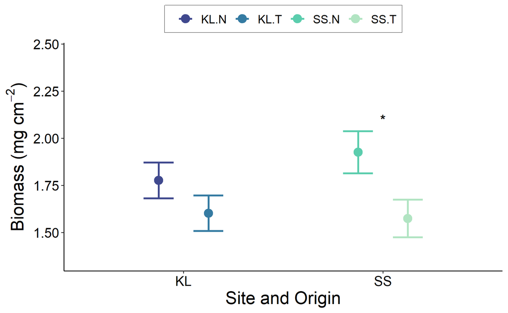

```r
##Summary statistics by Site and Origin
TP1_Bio.sum<-summarySE(Coral.TP1, measurevar="AFDW_mg.cm2", groupvars=c("Site", "Origin", "Site.Orig"), na.rm=TRUE)

##Plot Average Biomass across Treatments
TP1_Bio.plot<-ggplot(TP1_Bio.sum, aes(x=Site, y=AFDW_mg.cm2, colour=Site.Orig)) +
  scale_colour_manual(values=Orig.colors.o)+
  geom_errorbar(aes(ymin=AFDW_mg.cm2-se, ymax=AFDW_mg.cm2+se), width=cap.sz, linewidth=bar.sz, position=position_dodge(width=0.5)) +
  geom_point(size=point.sz, position=position_dodge(width=0.5))+
  theme_classic()+
  theme(axis.title.x = element_text(size = axis.title.sz),
        axis.title.y = element_text(size = axis.title.sz),
        axis.text.x=element_text(size=axis.txt.sz, colour="black"),
        axis.text.y=element_text(size=axis.txt.sz, colour="black"),
        legend.text=element_text(size=leg.txt.sz),
        legend.title=element_text(size=leg.title.sz),
        legend.box.background = element_rect(color = "black"),
        legend.position = "top")+
  labs(x="Site and Origin", y=expression(paste('Biomass (mg cm'^-2*")")), colour=NULL)+
  ylim(1.35, 2.45)+
   annotate("text", x=2, y=2.1, label="*", size=sig.sz, fontface="bold"); TP1_Bio.plot
```

#### Chlorophyll

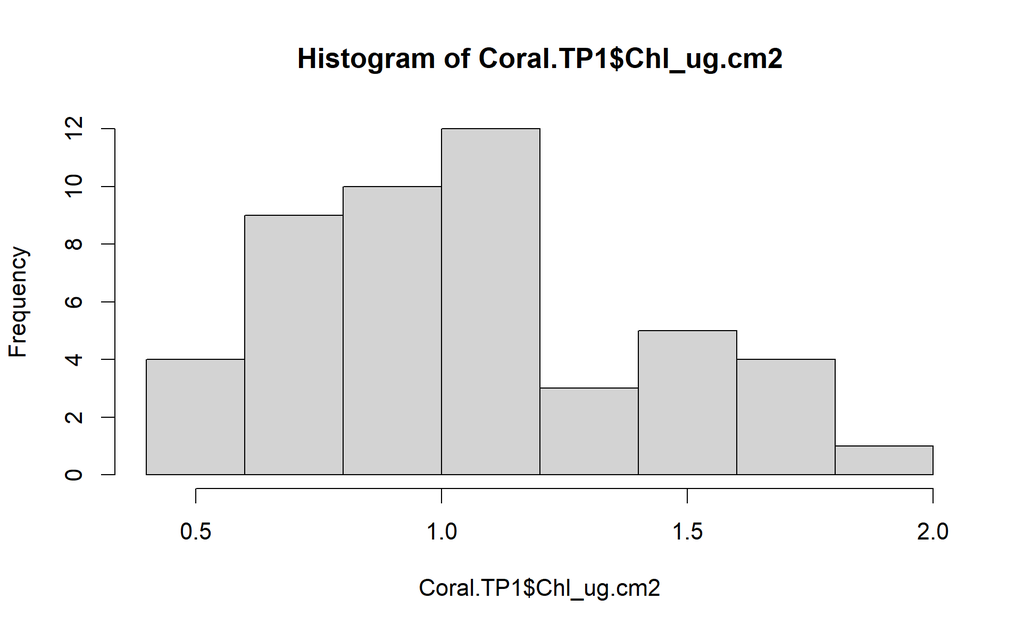

```r
##Check normality
hist(Coral.TP1$Chl_ug.cm2)
```

```r
shapiro.test(Coral.TP1$Chl_ug.cm2)
```

```
    Shapiro-Wilk normality test

data:  Coral.TP1$Chl_ug.cm2
W = 0.95564, p-value = 0.06727
```

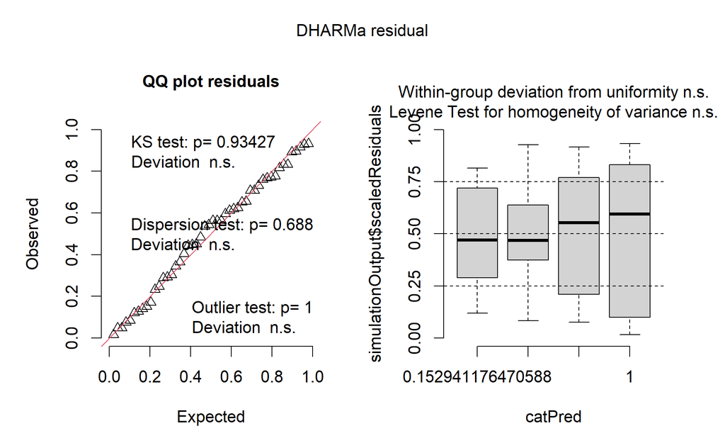

```r
#Normal

##Model
#Function of Site and Origin, with Genotype as a Random effect
#Interactions between Origin and Site
Chl.lme_TP1<-lmer(Chl_ug.cm2~Origin*Site+(1|Genotype), data=Coral.TP1)

##Check residuals
Chl.lme_res_TP1 <- simulateResiduals(fittedModel = Chl.lme_TP1, plot = F)
plot(Chl.lme_res_TP1)
```

```r
##Model results
summary(Chl.lme_TP1)
```

```
Linear mixed model fit by REML. t-tests use Satterthwaite's method ['lmerModLmerTest']
Formula: Chl_ug.cm2 ~ Origin * Site + (1 | Genotype)
   Data: Coral.TP1

REML criterion at convergence: -0.4

Scaled residuals:
    Min      1Q  Median      3Q     Max
-2.1377 -0.5871 -0.1548  0.6976  2.0162

Random effects:
 Groups   Name        Variance Std.Dev.
 Genotype (Intercept) 0.08669  0.2944
 Residual             0.03936  0.1984
Number of obs: 48, groups:  Genotype, 3

Fixed effects:
                        Estimate Std. Error       df t value Pr(>|t|)
(Intercept)              0.86074    0.17937  2.34405   4.799 0.029564 *
OriginTransplant         0.07568    0.08099 42.00000   0.934 0.355451
SiteSS                   0.54382    0.08099 42.00000   6.715 3.73e-08 ***
OriginTransplant:SiteSS -0.48115    0.11454 42.00000  -4.201 0.000136 ***
---
Signif. codes:  0 ‘***’ 0.001 ‘**’ 0.01 ‘*’ 0.05 ‘.’ 0.1 ‘ ’ 1

Correlation of Fixed Effects:
            (Intr) OrgnTr SiteSS
OrgnTrnspln -0.226
SiteSS      -0.226  0.500
OrgnTrn:SSS  0.160 -0.707 -0.707
```

```r
eta_squared(Chl.lme_TP1)
```

```
# Effect Size for ANOVA (Type III)

Parameter   | Eta2 (partial) |       95% CI
-------------------------------------------
Origin      |           0.16 | [0.03, 1.00]
Site        |           0.40 | [0.21, 1.00]
Origin:Site |           0.30 | [0.12, 1.00]

- One-sided CIs: upper bound fixed at [1.00].
```

```r
##Save model results
Chl_TP1.res<-data.frame(summary(Chl.lme_TP1)$coefficients[-1,])
Chl_TP1.res$Predictor<-c("Origin", "Site", "Origin x Site")
Chl_TP1.res$EtaSq<-c(eta_squared(Chl.lme_TP1)$Eta2)
Chl_TP1.res$Response<-rep("Chlorophyll", nrow(Chl_TP1.res))
```

```r
##Pairwise Comparisons of Interest
#Native vs Transplant within a Site
Chl.pair_TP1<-emmeans(Chl.lme_TP1, pairwise~Origin | Site)
Chl.pair_TP1
```

```
$emmeans
Site = KL:
 Origin     emmean    SE   df lower.CL upper.CL
 Native      0.861 0.179 2.34    0.188     1.53
 Transplant  0.936 0.179 2.34    0.264     1.61

Site = SS:
 Origin     emmean    SE   df lower.CL upper.CL
 Native      1.405 0.179 2.34    0.732     2.08
 Transplant  0.999 0.179 2.34    0.326     1.67

Degrees-of-freedom method: kenward-roger
Confidence level used: 0.95

$contrasts
Site = KL:
 contrast            estimate    SE df t.ratio p.value
 Native - Transplant  -0.0757 0.081 42  -0.934  0.3555

Site = SS:
 contrast            estimate    SE df t.ratio p.value
 Native - Transplant   0.4055 0.081 42   5.007  <.0001

Degrees-of-freedom method: kenward-roger
```

```r
#Calculate standardized effect sizes for pairwise comparisons
Chl.pair.es_TP1<-data.frame(eff_size(Chl.pair_TP1, sigma=sigma(Chl.lme_TP1), edf=df.residual(Chl.lme_TP1)))
```

```
Since 'object' is a list, we are using the contrasts already present.
```

```r
Chl.pair.es_TP1
```

|  | contrast | Site | effect.size | SE | df | lower.CL | upper.CL |
| --- | --- | --- | --- | --- | --- | --- | --- |
| 1 | (Native - Transplant) | KL | -0.3814574 | 0.4103644 | 42 | -1.209606 | 0.4466914 |
| 2 | (Native - Transplant) | SS | 2.0439056 | 0.4651875 | 42 | 1.105119 | 2.9826920 |

```r
Chl.pair.es_TP1<-Chl.pair.es_TP1 %>% dplyr::rename(contrast.se = contrast, SE.es = SE, df.es = df)

##Save Results
Chl.pair_TP1.res<-merge(data.frame(Chl.pair_TP1$contrasts), Chl.pair.es_TP1[,-c(1)])
Chl.pair_TP1.res$Response<-rep("Chlorophyll", nrow(Chl.pair_TP1.res))

##Add Significance levels
Chl.pair_TP1.res$Sig<-ifelse(Chl.pair_TP1.res$p.value<0.001, "***",
                              ifelse(Chl.pair_TP1.res$p.value<0.01, "**",
                                     ifelse(Chl.pair_TP1.res$p.value<0.05, "*",
                                            ifelse(Chl.pair_TP1.res$p.value<0.1, "-", NA))))
Chl.pair_TP1.res
```

| Site | contrast | estimate | SE | df | t.ratio | p.value | effect.size | SE.es | df.es | lower.CL | upper.CL | Response | Sig |
| --- | --- | --- | --- | --- | --- | --- | --- | --- | --- | --- | --- | --- | --- |
| KL | Native - Transplant | -0.07567521 | 0.08099011 | 42 | -0.934376 | 3.554512e-01 | -0.3814574 | 0.4103644 | 42 | -1.209606 | 0.4466914 | Chlorophyll | NA |
| SS | Native - Transplant | 0.40547907 | 0.08099011 | 42 | 5.006526 | 1.042242e-05 | 2.0439056 | 0.4651875 | 42 | 1.105119 | 2.9826920 | Chlorophyll | *** |

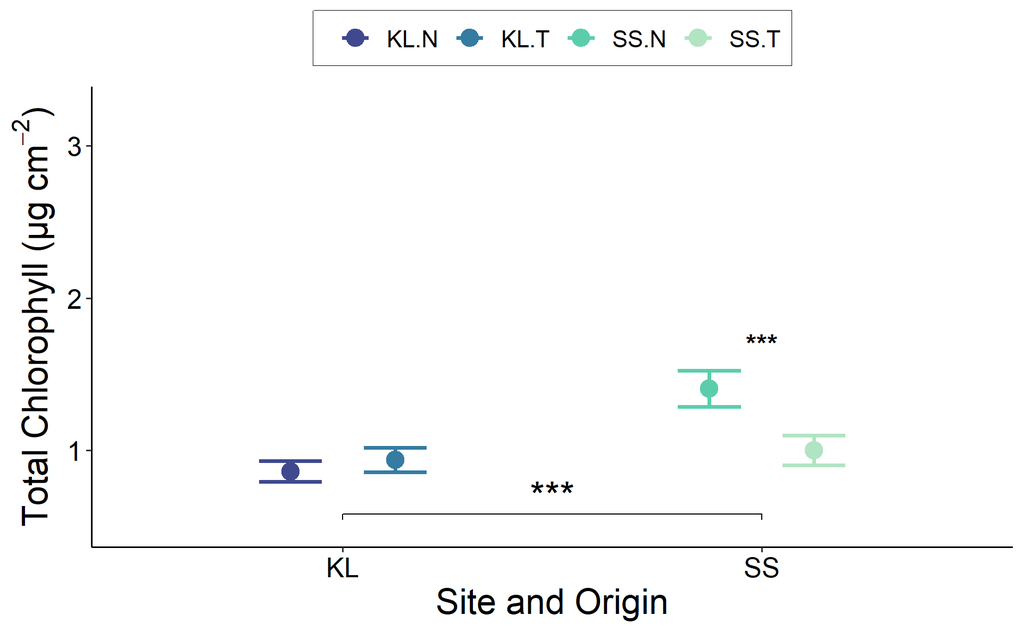

```r
##Summary statistics by Site and Origin
TP1_Chl.sum<-summarySE(Coral.TP1, measurevar="Chl_ug.cm2", groupvars=c("Site", "Origin", "Site.Orig"), na.rm=TRUE)

##Plot Average Chlorophyll across Treatments
TP1_Chl.plot<-ggplot(TP1_Chl.sum, aes(x=Site, y=Chl_ug.cm2, colour=Site.Orig)) +
  scale_colour_manual(values=Orig.colors.o)+
  geom_errorbar(aes(ymin=Chl_ug.cm2-se, ymax=Chl_ug.cm2+se), width=cap.sz, linewidth=bar.sz, position=position_dodge(width=0.5)) +
  geom_point(size=point.sz, position=position_dodge(width=0.5))+
  theme_classic()+
  theme(axis.title.x = element_text(size = axis.title.sz),
        axis.title.y = element_text(size = axis.title.sz),
        axis.text.x=element_text(size=axis.txt.sz, colour="black"),
        axis.text.y=element_text(size=axis.txt.sz, colour="black"),
        legend.text=element_text(size=leg.txt.sz),
        legend.title=element_text(size=leg.title.sz),
        legend.box.background = element_rect(color = "black"),
        legend.position="top")+
  labs(x="Site and Origin", y=expression(paste('Total Chlorophyll (\u03BCg cm'^-2*")")), colour=NULL)+
  ylim(0.5, 3.25)+
  annotate("text", x=2, y=1.7, label="***", size=sig.sz, fontface="bold")+
  geom_bracket(xmin=1, xmax=2, y.position=0.58, label.size=levels.sz, label="***", inherit.aes = FALSE); TP1_Chl.plot
```

#### Save Results

```r
##Combine Results
Phys_TP1.res<-rbind(Prot_TP1.res, Bio_TP1.res, Chl_TP1.res)
Phys.pair_TP1.res<-rbind(Prot.pair_TP1.res, Bio.pair_TP1.res, Chl.pair_TP1.res)

##Add Timepoint
Phys_TP1.res$TimeP<-rep("TP1", nrow(Phys_TP1.res))
Phys.pair_TP1.res$TimeP<-rep("TP1", nrow(Phys.pair_TP1.res))
```

### TP2

```r
##Subset Timepoint 2
Coral.TP2<-subset(Coral, TimeP=="TP2")
```

#### Protein

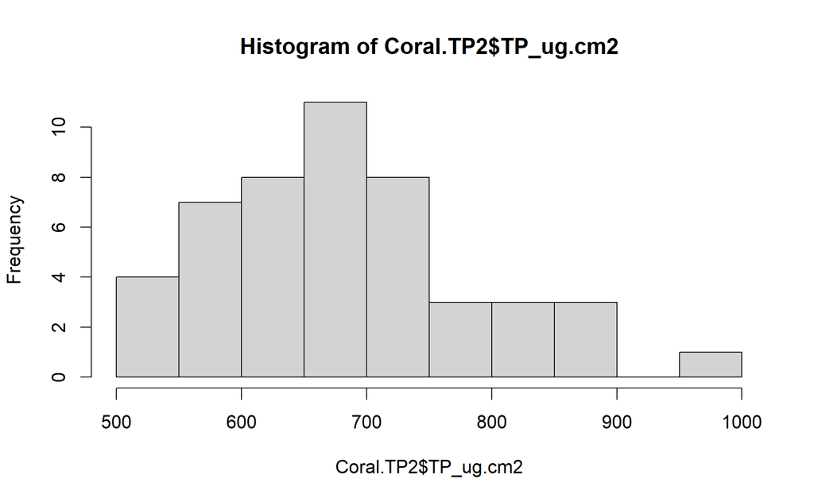

```r
##Check normality
hist(Coral.TP2$TP_ug.cm2)
```

```r
shapiro.test(Coral.TP2$TP_ug.cm2)
```

```
    Shapiro-Wilk normality test

data:  Coral.TP2$TP_ug.cm2
W = 0.97325, p-value = 0.3371
```

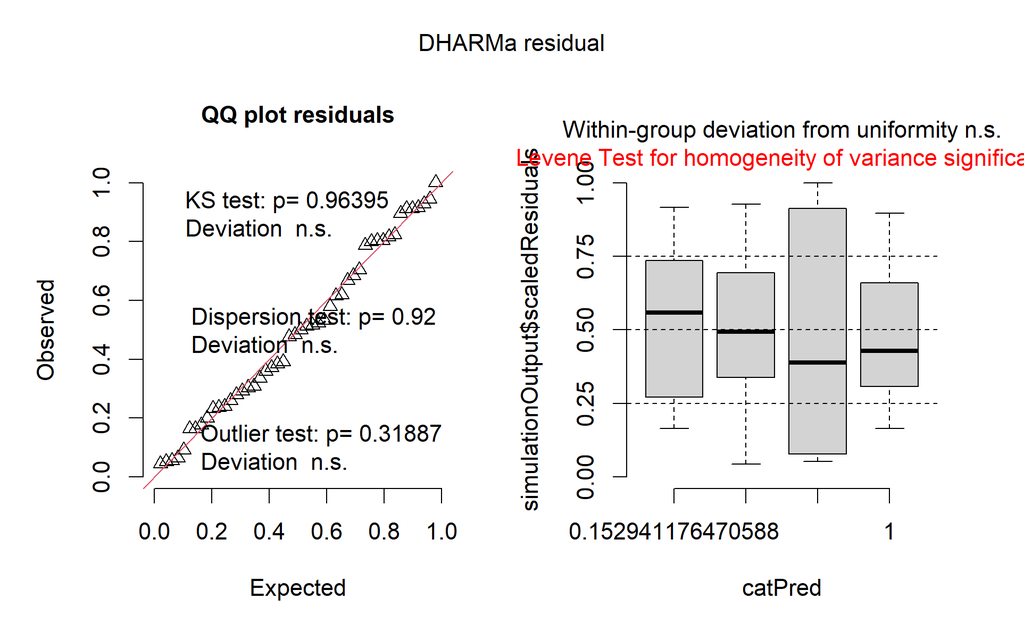

```r
#Normal

##Model
#Function of Site and Origin, with Genotype as a Random effect
#Interactions between Origin and Site
Prot.lme_TP2<-lmer(TP_ug.cm2~Origin*Site+(1|Genotype), data=Coral.TP2)

##Check residuals
Prot.lme_res_TP2 <- simulateResiduals(fittedModel = Prot.lme_TP2, plot = F)
plot(Prot.lme_res_TP2)
```

```r
##Model results
summary(Prot.lme_TP2)
```

```
Linear mixed model fit by REML. t-tests use Satterthwaite's method ['lmerModLmerTest']
Formula: TP_ug.cm2 ~ Origin * Site + (1 | Genotype)
   Data: Coral.TP2

REML criterion at convergence: 527.4

Scaled residuals:
    Min      1Q  Median      3Q     Max
-2.1392 -0.5188 -0.1549  0.5056  2.4411

Random effects:
 Groups   Name        Variance Std.Dev.
 Genotype (Intercept) 1487     38.56
 Residual             7009     83.72
Number of obs: 48, groups:  Genotype, 3

Fixed effects:
                        Estimate Std. Error     df t value Pr(>|t|)
(Intercept)               644.92      32.86   5.54  19.627 2.47e-06 ***
OriginTransplant          -31.44      34.18  42.00  -0.920   0.3629
SiteSS                     85.51      34.18  42.00   2.502   0.0163 *
OriginTransplant:SiteSS    43.75      48.34  42.00   0.905   0.3705
---
Signif. codes:  0 ‘***’ 0.001 ‘**’ 0.01 ‘*’ 0.05 ‘.’ 0.1 ‘ ’ 1

Correlation of Fixed Effects:
            (Intr) OrgnTr SiteSS
OrgnTrnspln -0.520
SiteSS      -0.520  0.500
OrgnTrn:SSS  0.368 -0.707 -0.707
```

```r
eta_squared(Prot.lme_TP2)
```

```
# Effect Size for ANOVA (Type III)

Parameter   | Eta2 (partial) |       95% CI
-------------------------------------------
Origin      |       3.71e-03 | [0.00, 1.00]
Site        |           0.32 | [0.14, 1.00]
Origin:Site |           0.02 | [0.00, 1.00]

- One-sided CIs: upper bound fixed at [1.00].
```

```r
##Save model results
Prot_TP2.res<-data.frame(summary(Prot.lme_TP2)$coefficients[-1,])
Prot_TP2.res$Predictor<-c("Origin", "Site", "Origin x Site")
Prot_TP2.res$EtaSq<-c(eta_squared(Prot.lme_TP2)$Eta2)
Prot_TP2.res$Response<-rep("Protein", nrow(Prot_TP2.res))
```

```r
##Pairwise Comparisons of Interest
#Native vs Transplant within a Site
Prot.pair_TP2<-emmeans(Prot.lme_TP2, pairwise~Origin | Site)
Prot.pair_TP2
```

```
$emmeans
Site = KL:
 Origin     emmean   SE   df lower.CL upper.CL
 Native        645 32.9 5.54      563      727
 Transplant    613 32.9 5.54      531      696

Site = SS:
 Origin     emmean   SE   df lower.CL upper.CL
 Native        730 32.9 5.54      648      812
 Transplant    743 32.9 5.54      661      825

Degrees-of-freedom method: kenward-roger
Confidence level used: 0.95

$contrasts
Site = KL:
 contrast            estimate   SE df t.ratio p.value
 Native - Transplant     31.4 34.2 42   0.920  0.3629

Site = SS:
 contrast            estimate   SE df t.ratio p.value
 Native - Transplant    -12.3 34.2 42  -0.360  0.7205

Degrees-of-freedom method: kenward-roger
```

```r
#Calculate standardized effect sizes for pairwise comparisons
Prot.pair.es_TP2<-data.frame(eff_size(Prot.pair_TP2, sigma=sigma(Prot.lme_TP2), edf=df.residual(Prot.lme_TP2)))
```

```
Since 'object' is a list, we are using the contrasts already present.
```

```r
Prot.pair.es_TP2
```

|  | contrast | Site | effect.size | SE | df | lower.CL | upper.CL |
| --- | --- | --- | --- | --- | --- | --- | --- |
| 1 | (Native - Transplant) | KL | 0.3755437 | 0.4102994 | 42 | -0.4524741 | 1.2035615 |
| 2 | (Native - Transplant) | SS | -0.1470749 | 0.4085636 | 42 | -0.9715895 | 0.6774398 |

```r
Prot.pair.es_TP2<-Prot.pair.es_TP2 %>% dplyr::rename(contrast.se = contrast, SE.es = SE, df.es = df)

##Save Results
Prot.pair_TP2.res<-merge(data.frame(Prot.pair_TP2$contrasts), Prot.pair.es_TP2[,-c(1)])
Prot.pair_TP2.res$Response<-rep("Protein", nrow(Prot.pair_TP2.res))

##Add Significance levels
Prot.pair_TP2.res$Sig<-ifelse(Prot.pair_TP2.res$p.value<0.001, "***",
                              ifelse(Prot.pair_TP2.res$p.value<0.01, "**",
                                     ifelse(Prot.pair_TP2.res$p.value<0.05, "*",
                                            ifelse(Prot.pair_TP2.res$p.value<0.1, "-", NA))))
Prot.pair_TP2.res
```

| Site | contrast | estimate | SE | df | t.ratio | p.value | effect.size | SE.es | df.es | lower.CL | upper.CL | Response | Sig |
| --- | --- | --- | --- | --- | --- | --- | --- | --- | --- | --- | --- | --- | --- |
| KL | Native - Transplant | 31.43980 | 34.17776 | 42 | 0.9198905 | 0.3628834 | 0.3755437 | 0.4102994 | 42 | -0.4524741 | 1.2035615 | Protein | NA |
| SS | Native - Transplant | -12.31282 | 34.17776 | 42 | -0.3602584 | 0.7204594 | -0.1470749 | 0.4085636 | 42 | -0.9715895 | 0.6774398 | Protein | NA |

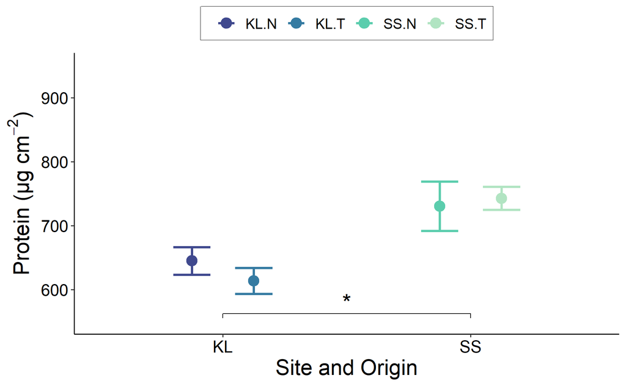

```r
##Summary statistics by Site and Origin
TP2_Prot.sum<-summarySE(Coral.TP2, measurevar="TP_ug.cm2", groupvars=c("Site", "Origin", "Site.Orig"), na.rm=TRUE)

##Plot Average Protein across Treatments
TP2_Prot.plot<-ggplot(TP2_Prot.sum, aes(x=Site, y=TP_ug.cm2, colour=Site.Orig)) +
  scale_colour_manual(values=Orig.colors.o)+
  geom_errorbar(aes(ymin=TP_ug.cm2-se, ymax=TP_ug.cm2+se), width=cap.sz, linewidth=bar.sz, position=position_dodge(width=0.5)) +
  geom_point(size=point.sz, position=position_dodge(width=0.5))+
  theme_classic()+
  theme(axis.title.x = element_text(size = axis.title.sz),
        axis.title.y = element_text(size = axis.title.sz),
        axis.text.x=element_text(size=axis.txt.sz, colour="black"),
        axis.text.y=element_text(size=axis.txt.sz, colour="black"),
        legend.text=element_text(size=leg.txt.sz),
        legend.title=element_text(size=leg.title.sz),
        legend.box.background = element_rect(color = "black"),
        legend.position="top")+
  labs(x="Site and Origin", y=expression(paste('Protein (\u03BCg cm'^-2*")")), colour=NULL)+
  ylim(550, 950)+
  geom_bracket(xmin=1, xmax=2, y.position=562, label.size=levels.sz, label="*", inherit.aes = FALSE); TP2_Prot.plot
```

#### Biomass

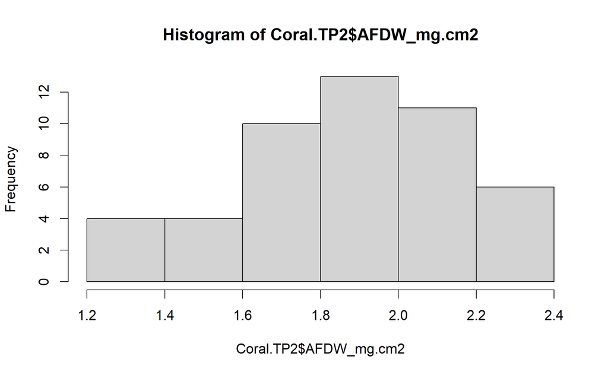

```r
##Check normality
hist(Coral.TP2$AFDW_mg.cm2)
```

```r
shapiro.test(Coral.TP2$AFDW_mg.cm2)
```

```
    Shapiro-Wilk normality test

data:  Coral.TP2$AFDW_mg.cm2
W = 0.97072, p-value = 0.2701
```

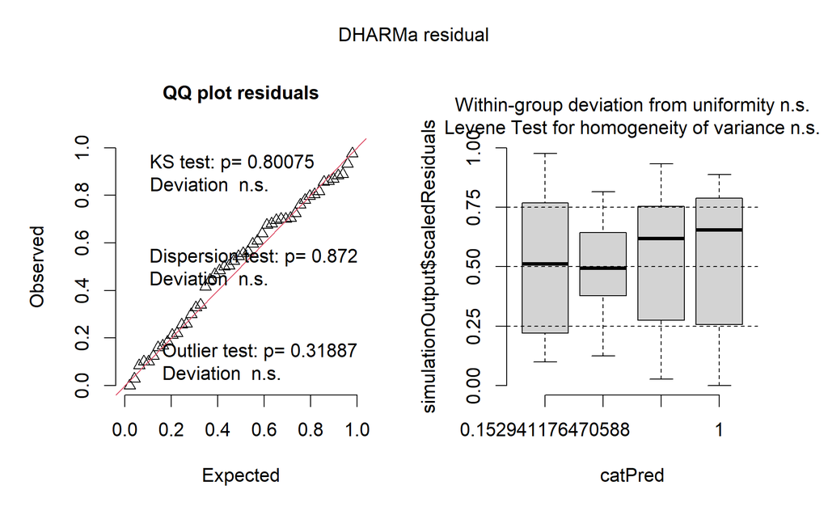

```r
#Normal

##Model
#Function of Site and Origin, with Genotype as a Random effect
#Interactions between Origin and Site
Bio.lme_TP2<-lmer(AFDW_mg.cm2~Origin*Site+(1|Genotype), data=Coral.TP2)

##Check residuals
Bio.lme_res_TP2 <- simulateResiduals(fittedModel = Bio.lme_TP2, plot = F)
plot(Bio.lme_res_TP2)
```

```r
##Model results
summary(Bio.lme_TP2)
```

```
Linear mixed model fit by REML. t-tests use Satterthwaite's method ['lmerModLmerTest']
Formula: AFDW_mg.cm2 ~ Origin * Site + (1 | Genotype)
   Data: Coral.TP2

REML criterion at convergence: 5.1

Scaled residuals:
    Min      1Q  Median      3Q     Max
-3.0314 -0.5318  0.1778  0.6946  1.6207

Random effects:
 Groups   Name        Variance Std.Dev.
 Genotype (Intercept) 0.006051 0.07779
 Residual             0.049961 0.22352
Number of obs: 48, groups:  Genotype, 3

Fixed effects:
                        Estimate Std. Error       df t value Pr(>|t|)
(Intercept)              1.87874    0.07862  7.78345  23.898 1.45e-08 ***
OriginTransplant        -0.22229    0.09125 42.00000  -2.436  0.01917 *
SiteSS                   0.01743    0.09125 42.00000   0.191  0.84941
OriginTransplant:SiteSS  0.37082    0.12905 42.00000   2.874  0.00634 **
---
Signif. codes:  0 ‘***’ 0.001 ‘**’ 0.01 ‘*’ 0.05 ‘.’ 0.1 ‘ ’ 1

Correlation of Fixed Effects:
            (Intr) OrgnTr SiteSS
OrgnTrnspln -0.580
SiteSS      -0.580  0.500
OrgnTrn:SSS  0.410 -0.707 -0.707
```

```r
eta_squared(Bio.lme_TP2)
```

```
# Effect Size for ANOVA (Type III)

Parameter   | Eta2 (partial) |       95% CI
-------------------------------------------
Origin      |       7.72e-03 | [0.00, 1.00]
Site        |           0.19 | [0.04, 1.00]
Origin:Site |           0.16 | [0.03, 1.00]

- One-sided CIs: upper bound fixed at [1.00].
```

```r
##Save model results
Bio_TP2.res<-data.frame(summary(Bio.lme_TP2)$coefficients[-1,])
Bio_TP2.res$Predictor<-c("Origin", "Site", "Origin x Site")
Bio_TP2.res$EtaSq<-c(eta_squared(Bio.lme_TP2)$Eta2)
Bio_TP2.res$Response<-rep("Biomass", nrow(Bio_TP2.res))
```

```r
##Pairwise Comparisons of Interest
#Native vs Transplant within a Site
Bio.pair_TP2<-emmeans(Bio.lme_TP2, pairwise~Origin | Site)
Bio.pair_TP2
```

```
$emmeans
Site = KL:
 Origin     emmean     SE   df lower.CL upper.CL
 Native       1.88 0.0786 7.78     1.70     2.06
 Transplant   1.66 0.0786 7.78     1.47     1.84

Site = SS:
 Origin     emmean     SE   df lower.CL upper.CL
 Native       1.90 0.0786 7.78     1.71     2.08
 Transplant   2.04 0.0786 7.78     1.86     2.23

Degrees-of-freedom method: kenward-roger
Confidence level used: 0.95

$contrasts
Site = KL:
 contrast            estimate     SE df t.ratio p.value
 Native - Transplant    0.222 0.0913 42   2.436  0.0192

Site = SS:
 contrast            estimate     SE df t.ratio p.value
 Native - Transplant   -0.149 0.0913 42  -1.628  0.1111

Degrees-of-freedom method: kenward-roger
```

```r
#Calculate standardized effect sizes for pairwise comparisons
Bio.pair.es_TP2<-data.frame(eff_size(Bio.pair_TP2, sigma=sigma(Bio.lme_TP2), edf=df.residual(Bio.lme_TP2)))
```

```
Since 'object' is a list, we are using the contrasts already present.
```

```r
Bio.pair.es_TP2
```

|  | contrast | Site | effect.size | SE | df | lower.CL | upper.CL |
| --- | --- | --- | --- | --- | --- | --- | --- |
| 1 | (Native - Transplant) | KL | 0.9945027 | 0.4224227 | 42 | 0.1420193 | 1.8469862 |
| 2 | (Native - Transplant) | SS | -0.6645232 | 0.4146368 | 42 | -1.5012942 | 0.1722478 |

```r
Bio.pair.es_TP2<-Bio.pair.es_TP2 %>% dplyr::rename(contrast.se = contrast, SE.es = SE, df.es = df)

##Save Results
Bio.pair_TP2.res<-merge(data.frame(Bio.pair_TP2$contrasts), Bio.pair.es_TP2[,-c(1)])
Bio.pair_TP2.res$Response<-rep("Biomass", nrow(Bio.pair_TP2.res))

##Add Significance levels
Bio.pair_TP2.res$Sig<-ifelse(Bio.pair_TP2.res$p.value<0.001, "***",
                              ifelse(Bio.pair_TP2.res$p.value<0.01, "**",
                                     ifelse(Bio.pair_TP2.res$p.value<0.05, "*",
                                            ifelse(Bio.pair_TP2.res$p.value<0.1, "-", NA))))
Bio.pair_TP2.res
```

| Site | contrast | estimate | SE | df | t.ratio | p.value | effect.size | SE.es | df.es | lower.CL | upper.CL | Response | Sig |
| --- | --- | --- | --- | --- | --- | --- | --- | --- | --- | --- | --- | --- | --- |
| KL | Native - Transplant | 0.2222908 | 0.09125147 | 42 | 2.436024 | 0.01917197 | 0.9945027 | 0.4224227 | 42 | 0.1420193 | 1.8469862 | Biomass | * |
| SS | Native - Transplant | -0.1485339 | 0.09125147 | 42 | -1.627743 | 0.11105928 | -0.6645232 | 0.4146368 | 42 | -1.5012942 | 0.1722478 | Biomass | NA |

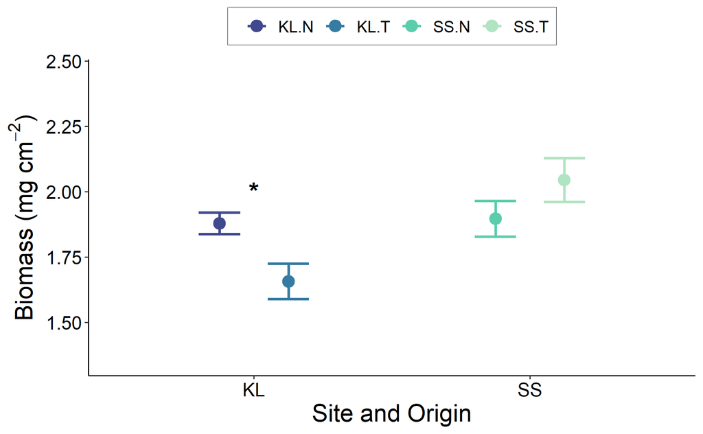

```r
##Summary statistics by Site and Origin
TP2_Bio.sum<-summarySE(Coral.TP2, measurevar="AFDW_mg.cm2", groupvars=c("Site", "Origin", "Site.Orig"), na.rm=TRUE)

##Plot Average Biomass across Treatments
TP2_Bio.plot<-ggplot(TP2_Bio.sum, aes(x=Site, y=AFDW_mg.cm2, colour=Site.Orig)) +
  scale_colour_manual(values=Orig.colors.o)+
  geom_errorbar(aes(ymin=AFDW_mg.cm2-se, ymax=AFDW_mg.cm2+se), width=cap.sz, linewidth=bar.sz, position=position_dodge(width=0.5)) +
  geom_point(size=point.sz, position=position_dodge(width=0.5))+
  theme_classic()+
  theme(axis.title.x = element_text(size = axis.title.sz),
        axis.title.y = element_text(size = axis.title.sz),
        axis.text.x=element_text(size=axis.txt.sz, colour="black"),
        axis.text.y=element_text(size=axis.txt.sz, colour="black"),
        legend.text=element_text(size=leg.txt.sz),
        legend.title=element_text(size=leg.title.sz),
        legend.box.background = element_rect(color = "black"),
        legend.position="top")+
  labs(x="Site and Origin", y=expression(paste('Biomass (mg cm'^-2*")")), colour=NULL)+
  ylim(1.35, 2.45)+
  annotate("text", x=1, y=2, label="*", size=levels.sz, fontface="bold"); TP2_Bio.plot
```

#### Chlorophyll

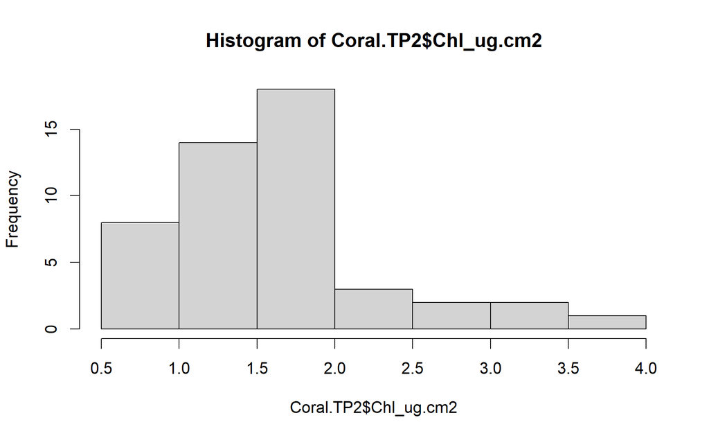

```r
##Check normality
hist(Coral.TP2$Chl_ug.cm2)
```

```r
shapiro.test(Coral.TP2$Chl_ug.cm2)
```

```
    Shapiro-Wilk normality test

data:  Coral.TP2$Chl_ug.cm2
W = 0.89322, p-value = 0.0003826
```

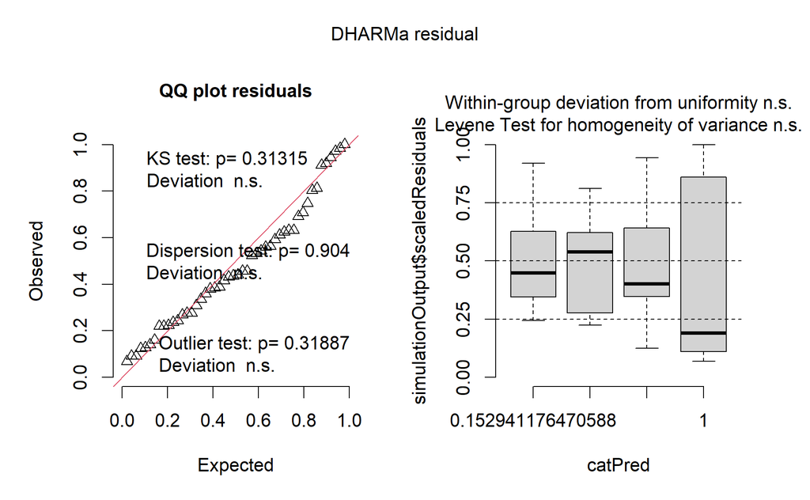

```r
#Normal

##Model
#Function of Site and Origin, with Genotype as a Random effect
#Interactions between Origin and Site
Chl.lme_TP2<-lmer(Chl_ug.cm2~Origin*Site+(1|Genotype), data=Coral.TP2)

##Check residuals
Chl.lme_res_TP2 <- simulateResiduals(fittedModel = Chl.lme_TP2, plot = F)
plot(Chl.lme_res_TP2)
```

```r
##Model results
summary(Chl.lme_TP2)
```

```
Linear mixed model fit by REML. t-tests use Satterthwaite's method ['lmerModLmerTest']
Formula: Chl_ug.cm2 ~ Origin * Site + (1 | Genotype)
   Data: Coral.TP2

REML criterion at convergence: 60.1

Scaled residuals:
    Min      1Q  Median      3Q     Max
-1.5646 -0.6834 -0.2260  0.6331  2.9227

Random effects:
 Groups   Name        Variance Std.Dev.
 Genotype (Intercept) 0.02999  0.1732
 Residual             0.17246  0.4153
Number of obs: 48, groups:  Genotype, 3

Fixed effects:
                        Estimate Std. Error      df t value Pr(>|t|)
(Intercept)               1.2824     0.1561  6.2441   8.216 0.000142 ***
OriginTransplant         -0.2475     0.1695 42.0000  -1.460 0.151795
SiteSS                    0.5567     0.1695 42.0000   3.284 0.002071 **
OriginTransplant:SiteSS   0.6593     0.2398 42.0000   2.750 0.008761 **
---
Signif. codes:  0 ‘***’ 0.001 ‘**’ 0.01 ‘*’ 0.05 ‘.’ 0.1 ‘ ’ 1

Correlation of Fixed Effects:
            (Intr) OrgnTr SiteSS
OrgnTrnspln -0.543
SiteSS      -0.543  0.500
OrgnTrn:SSS  0.384 -0.707 -0.707
```

```r
eta_squared(Chl.lme_TP2)
```

```
# Effect Size for ANOVA (Type III)

Parameter   | Eta2 (partial) |       95% CI
-------------------------------------------
Origin      |           0.01 | [0.00, 1.00]
Site        |           0.57 | [0.40, 1.00]
Origin:Site |           0.15 | [0.02, 1.00]

- One-sided CIs: upper bound fixed at [1.00].
```

```r
##Save model results
Chl_TP2.res<-data.frame(summary(Chl.lme_TP2)$coefficients[-1,])
Chl_TP2.res$Predictor<-c("Origin", "Site", "Origin x Site")
Chl_TP2.res$EtaSq<-c(eta_squared(Chl.lme_TP2)$Eta2)
Chl_TP2.res$Response<-rep("Chlorophyll", nrow(Chl_TP2.res))
```

```r
##Pairwise Comparisons of Interest
#Native vs Transplant within a Site
Chl.pair_TP2<-emmeans(Chl.lme_TP2, pairwise~Origin | Site)
Chl.pair_TP2
```

```
$emmeans
Site = KL:
 Origin     emmean    SE   df lower.CL upper.CL
 Native       1.28 0.156 6.24    0.904     1.66
 Transplant   1.03 0.156 6.24    0.657     1.41

Site = SS:
 Origin     emmean    SE   df lower.CL upper.CL
 Native       1.84 0.156 6.24    1.461     2.22
 Transplant   2.25 0.156 6.24    1.873     2.63

Degrees-of-freedom method: kenward-roger
Confidence level used: 0.95

$contrasts
Site = KL:
 contrast            estimate   SE df t.ratio p.value
 Native - Transplant    0.247 0.17 42   1.460  0.1518

Site = SS:
 contrast            estimate   SE df t.ratio p.value
 Native - Transplant   -0.412 0.17 42  -2.429  0.0195

Degrees-of-freedom method: kenward-roger
```

```r
#Calculate standardized effect sizes for pairwise comparisons
Chl.pair.es_TP2<-data.frame(eff_size(Chl.pair_TP2, sigma=sigma(Chl.lme_TP2), edf=df.residual(Chl.lme_TP2)))
```

```
Since 'object' is a list, we are using the contrasts already present.
```

```r
Chl.pair.es_TP2
```

|  | contrast | Site | effect.size | SE | df | lower.CL | upper.CL |
| --- | --- | --- | --- | --- | --- | --- | --- |
| 1 | (Native - Transplant) | KL | 0.5959464 | 0.4133941 | 42 | -0.2383166 | 1.4302094 |
| 2 | (Native - Transplant) | SS | -0.9915456 | 0.4223399 | 42 | -1.8438620 | -0.1392292 |

```r
Chl.pair.es_TP2<-Chl.pair.es_TP2 %>% dplyr::rename(contrast.se = contrast, SE.es = SE, df.es = df)

##Save Results
Chl.pair_TP2.res<-merge(data.frame(Chl.pair_TP2$contrasts), Chl.pair.es_TP2[,-c(1)])
Chl.pair_TP2.res$Response<-rep("Chlorophyll", nrow(Chl.pair_TP2.res))

##Add Significance levels
Chl.pair_TP2.res$Sig<-ifelse(Chl.pair_TP2.res$p.value<0.001, "***",
                              ifelse(Chl.pair_TP2.res$p.value<0.01, "**",
                                     ifelse(Chl.pair_TP2.res$p.value<0.05, "*",
                                            ifelse(Chl.pair_TP2.res$p.value<0.1, "-", NA))))
Chl.pair_TP2.res
```

| Site | contrast | estimate | SE | df | t.ratio | p.value | effect.size | SE.es | df.es | lower.CL | upper.CL | Response | Sig |
| --- | --- | --- | --- | --- | --- | --- | --- | --- | --- | --- | --- | --- | --- |
| KL | Native - Transplant | 0.2474839 | 0.1695369 | 42 | 1.459765 | 0.15179466 | 0.5959464 | 0.4133941 | 42 | -0.2383166 | 1.4302094 | Chlorophyll | NA |
| SS | Native - Transplant | -0.4117679 | 0.1695369 | 42 | -2.428781 | 0.01950982 | -0.9915456 | 0.4223399 | 42 | -1.8438620 | -0.1392292 | Chlorophyll | * |

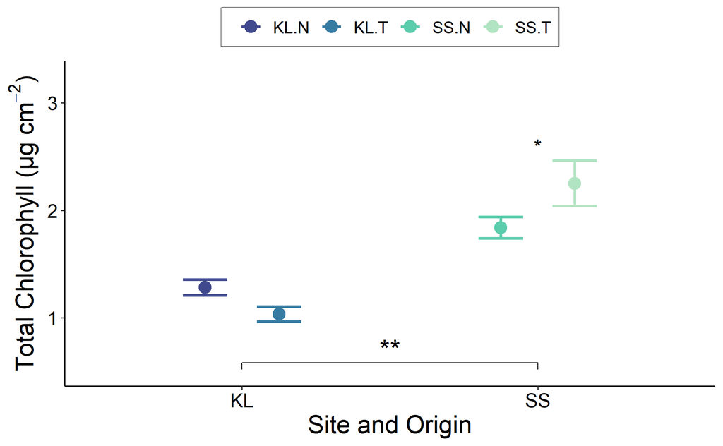

```r
##Summary statistics by Site and Origin
TP2_Chl.sum<-summarySE(Coral.TP2, measurevar="Chl_ug.cm2", groupvars=c("Site", "Origin", "Site.Orig"), na.rm=TRUE)

##Plot Average Chlorophyll across Treatments
TP2_Chl.plot<-ggplot(TP2_Chl.sum, aes(x=Site, y=Chl_ug.cm2, colour=Site.Orig)) +
  scale_colour_manual(values=Orig.colors.o)+
  geom_errorbar(aes(ymin=Chl_ug.cm2-se, ymax=Chl_ug.cm2+se), width=cap.sz, linewidth=bar.sz, position=position_dodge(width=0.5)) +
  geom_point(size=point.sz, position=position_dodge(width=0.5))+
  theme_classic()+
  theme(axis.title.x = element_text(size = axis.title.sz),
        axis.title.y = element_text(size = axis.title.sz),
        axis.text.x=element_text(size=axis.txt.sz, colour="black"),
        axis.text.y=element_text(size=axis.txt.sz, colour="black"),
        legend.text=element_text(size=leg.txt.sz),
        legend.title=element_text(size=leg.title.sz),
        legend.box.background = element_rect(color = "black"),
        legend.position= "top")+
  labs(x="Site and Origin", y=expression(paste('Total Chlorophyll (\u03BCg cm'^-2*")")), colour=NULL)+
  ylim(0.5, 3.25)+
  annotate("text", x=2, y=2.6, label="*", size=sig.sz, fontface="bold")+
  geom_bracket(xmin=1, xmax=2, y.position=0.58, label.size=levels.sz, label="**", inherit.aes = FALSE); TP2_Chl.plot
```

#### Save Results

```r
##Combine Results
Phys_TP2.res<-rbind(Prot_TP2.res, Bio_TP2.res, Chl_TP2.res)
Phys.pair_TP2.res<-rbind(Prot.pair_TP2.res, Bio.pair_TP2.res, Chl.pair_TP2.res)

##Add Timepoint
Phys_TP2.res$TimeP<-rep("TP2", nrow(Phys_TP2.res))
Phys.pair_TP2.res$TimeP<-rep("TP2", nrow(Phys.pair_TP2.res))
```

### TP3

```r
##Subset Timepoint 3
Coral.TP3<-subset(Coral, TimeP=="TP3")
```

#### Protein

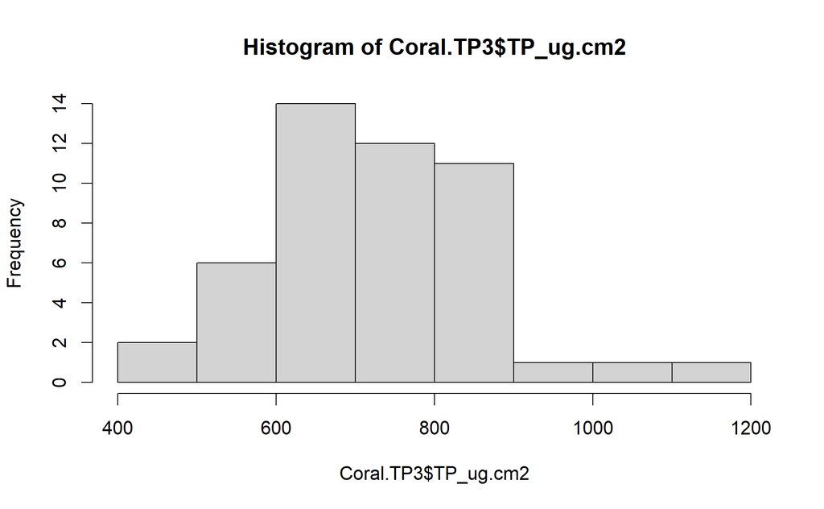

```r
##Check normality
hist(Coral.TP3$TP_ug.cm2)
```

```r
shapiro.test(Coral.TP3$TP_ug.cm2)
```

```
    Shapiro-Wilk normality test

data:  Coral.TP3$TP_ug.cm2
W = 0.97251, p-value = 0.3164
```

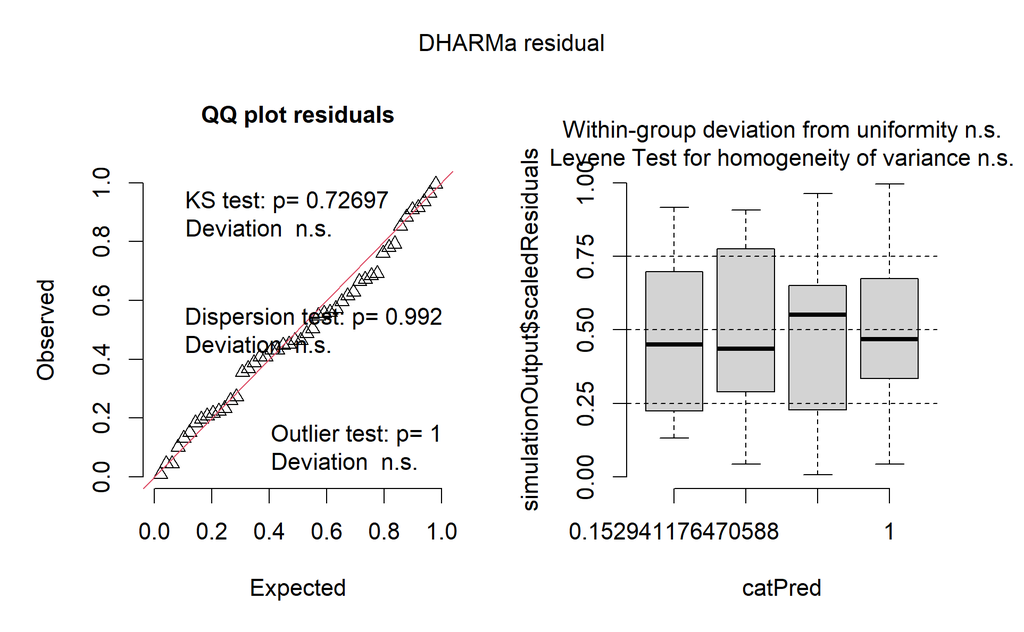

```r
#Normal

##Model
#Function of Site and Origin, with Genotype as a Random effect
#Interactions between Origin and Site
Prot.lme_TP3<-lmer(TP_ug.cm2~Origin*Site+(1|Genotype), data=Coral.TP3)

##Check residuals
Prot.lme_res_TP3 <- simulateResiduals(fittedModel = Prot.lme_TP3, plot = F)
plot(Prot.lme_res_TP3)
```

```r
##Model results
summary(Prot.lme_TP3)
```

```
Linear mixed model fit by REML. t-tests use Satterthwaite's method ['lmerModLmerTest']
Formula: TP_ug.cm2 ~ Origin * Site + (1 | Genotype)
   Data: Coral.TP3

REML criterion at convergence: 557.9

Scaled residuals:
     Min       1Q   Median       3Q      Max
-2.10550 -0.62928 -0.08111  0.60540  2.38260

Random effects:
 Groups   Name        Variance Std.Dev.
 Genotype (Intercept)  4585     67.71
 Residual             13806    117.50
Number of obs: 48, groups:  Genotype, 3

Fixed effects:
                        Estimate Std. Error      df t value Pr(>|t|)
(Intercept)              704.614     51.757   4.306  13.614 0.000106 ***
OriginTransplant         -59.408     47.969  42.000  -1.238 0.222421
SiteSS                    65.746     47.969  42.000   1.371 0.177784
OriginTransplant:SiteSS   47.120     67.839  42.000   0.695 0.491140
---
Signif. codes:  0 ‘***’ 0.001 ‘**’ 0.01 ‘*’ 0.05 ‘.’ 0.1 ‘ ’ 1

Correlation of Fixed Effects:
            (Intr) OrgnTr SiteSS
OrgnTrnspln -0.463
SiteSS      -0.463  0.500
OrgnTrn:SSS  0.328 -0.707 -0.707
```

```r
eta_squared(Prot.lme_TP3)
```

```
# Effect Size for ANOVA (Type III)

Parameter   | Eta2 (partial) |       95% CI
-------------------------------------------
Origin      |           0.03 | [0.00, 1.00]
Site        |           0.14 | [0.02, 1.00]
Origin:Site |           0.01 | [0.00, 1.00]

- One-sided CIs: upper bound fixed at [1.00].
```

```r
##Save model results
Prot_TP3.res<-data.frame(summary(Prot.lme_TP3)$coefficients[-1,])
Prot_TP3.res$Predictor<-c("Origin", "Site", "Origin x Site")
Prot_TP3.res$EtaSq<-c(eta_squared(Prot.lme_TP3)$Eta2)
Prot_TP3.res$Response<-rep("Protein", nrow(Prot_TP3.res))
```

```r
##Pairwise Comparisons of Interest
#Native vs Transplant within a Site
Prot.pair_TP3<-emmeans(Prot.lme_TP3, pairwise~Origin | Site)
Prot.pair_TP3
```

```
$emmeans
Site = KL:
 Origin     emmean   SE   df lower.CL upper.CL
 Native        705 51.8 4.31      565      844
 Transplant    645 51.8 4.31      505      785

Site = SS:
 Origin     emmean   SE   df lower.CL upper.CL
 Native        770 51.8 4.31      631      910
 Transplant    758 51.8 4.31      618      898

Degrees-of-freedom method: kenward-roger
Confidence level used: 0.95

$contrasts
Site = KL:
 contrast            estimate SE df t.ratio p.value
 Native - Transplant     59.4 48 42   1.238  0.2224

Site = SS:
 contrast            estimate SE df t.ratio p.value
 Native - Transplant     12.3 48 42   0.256  0.7991

Degrees-of-freedom method: kenward-roger
```

```r
#Calculate standardized effect sizes for pairwise comparisons
Prot.pair.es_TP3<-data.frame(eff_size(Prot.pair_TP3, sigma=sigma(Prot.lme_TP3), edf=df.residual(Prot.lme_TP3)))
```

```
Since 'object' is a list, we are using the contrasts already present.
```

```r
Prot.pair.es_TP3
```

|  | contrast | Site | effect.size | SE | df | lower.CL | upper.CL |
| --- | --- | --- | --- | --- | --- | --- | --- |
| 1 | (Native - Transplant) | KL | 0.5056015 | 0.4119586 | 42 | -0.3257647 | 1.336968 |
| 2 | (Native - Transplant) | SS | 0.1045828 | 0.4084077 | 42 | -0.7196174 | 0.928783 |

```r
Prot.pair.es_TP3<-Prot.pair.es_TP3 %>% dplyr::rename(contrast.se = contrast, SE.es = SE, df.es = df)

##Save Results
Prot.pair_TP3.res<-merge(data.frame(Prot.pair_TP3$contrasts), Prot.pair.es_TP3[,-c(1)])
Prot.pair_TP3.res$Response<-rep("Protein", nrow(Prot.pair_TP3.res))

##Add Significance levels
Prot.pair_TP3.res$Sig<-ifelse(Prot.pair_TP3.res$p.value<0.001, "***",
                              ifelse(Prot.pair_TP3.res$p.value<0.01, "**",
                                     ifelse(Prot.pair_TP3.res$p.value<0.05, "*",
                                            ifelse(Prot.pair_TP3.res$p.value<0.1, "-", NA))))
Prot.pair_TP3.res
```

| Site | contrast | estimate | SE | df | t.ratio | p.value | effect.size | SE.es | df.es | lower.CL | upper.CL | Response | Sig |
| --- | --- | --- | --- | --- | --- | --- | --- | --- | --- | --- | --- | --- | --- |
| KL | Native - Transplant | 59.40810 | 47.96911 | 42 | 1.2384657 | 0.2224210 | 0.5056015 | 0.4119586 | 42 | -0.3257647 | 1.336968 | Protein | NA |
| SS | Native - Transplant | 12.28846 | 47.96911 | 42 | 0.2561745 | 0.7990667 | 0.1045828 | 0.4084077 | 42 | -0.7196174 | 0.928783 | Protein | NA |

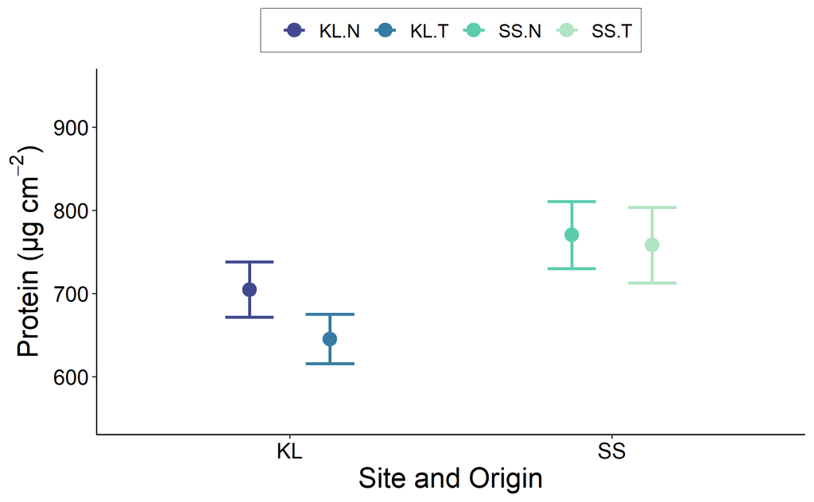

```r
##Summary statistics by Site and Origin
TP3_Prot.sum<-summarySE(Coral.TP3, measurevar="TP_ug.cm2", groupvars=c("Site", "Origin", "Site.Orig"), na.rm=TRUE)

##Plot Average Protein across Treatments
TP3_Prot.plot<-ggplot(TP3_Prot.sum, aes(x=Site, y=TP_ug.cm2, colour=Site.Orig)) +
  scale_colour_manual(values=Orig.colors.o)+
  geom_errorbar(aes(ymin=TP_ug.cm2-se, ymax=TP_ug.cm2+se), width=cap.sz, linewidth=bar.sz, position=position_dodge(width=0.5)) +
  geom_point(size=point.sz, position=position_dodge(width=0.5))+
  theme_classic()+
  theme(axis.title.x = element_text(size = axis.title.sz),
        axis.title.y = element_text(size = axis.title.sz),
        axis.text.x=element_text(size=axis.txt.sz, colour="black"),
        axis.text.y=element_text(size=axis.txt.sz, colour="black"),
        legend.text=element_text(size=leg.txt.sz),
        legend.title=element_text(size=leg.title.sz),
        legend.box.background = element_rect(color = "black"),
        legend.position="top")+
  labs(x="Site and Origin", y=expression(paste('Protein (\u03BCg cm'^-2*")")), colour=NULL)+
  ylim(550, 950); TP3_Prot.plot
```